# Classifying each person’s response curve

### Layer 2 — turning a curve into survey responses

```python
def response_sd(mu):
    """SD of a single response, given the true value `mu` at that midpoint.

    All three models give the same SD at the top of a peak, so signal-to-noise
    where the signal lives is unchanged and only the quiet end of the curve
    moves. See 8.2.
    """
    if NOISE_MODEL == 'constant':
        return np.full_like(np.asarray(mu, dtype=float), SLIDER_SD)
    peak_val = BASELINE + PEAK_AMP
    if NOISE_MODEL == 'proportional':
        return SLIDER_SD * np.asarray(mu, dtype=float) / peak_val
    if NOISE_MODEL == 'floor':
        return np.sqrt(NOISE_FLOOR ** 2 + (SLIDER_SD * np.asarray(mu, dtype=float)
                                           / peak_val) ** 2)
    raise ValueError(NOISE_MODEL)

def simulate_person(shape, n_points, sep, reps=None):
    """One person's data: n_points midpoints, each rated `reps` times."""
    reps = REPS if reps is None else reps
    p = draw_person_params(shape, sep)
    x = np.repeat(np.linspace(MID_LO, MID_HI, n_points), reps)
    mu = true_curve(x, shape, p)
    y = mu + rng.normal(0, 1, x.size) * response_sd(mu)
    return x, np.clip(y, 0, SLIDER_MAX), p    # sliders are bounded at 0 and 100

def simulate_population(n_people, n_points, sep, mix=None):
    """A population with known ground truth for every person."""
    mix = mix or SHAPE_MIX
    shapes = [s for s, f in mix.items() for _ in range(int(round(f * n_people)))]
    while len(shapes) < n_people:
        shapes.append(max(mix, key=mix.get))
    shapes = shapes[:n_people]
    rng.shuffle(shapes)
    return [(s,) + simulate_person(s, n_points, sep)[:2] for s in shapes]
```

**TipDefinition of `PEAK_W`**

A participant’s reference point is not infinitely sharp. Near it, a fixed rating gap feels large; far from it, the same gap feels small. `PEAK_W` is **the distance from the reference point over which that heightened sensitivity fades**, in star units.

Formally it is the `w` in the bell curve `exp(-0.5 * ((x - m) / w) ** 2)` — the standard deviation of the bump. The name is a poor one: it is *not* the width at half height. The translations that matter:

| distance from the reference point | height, as a fraction of the peak |
| --- | --- |
| `1 * PEAK_W` | 61% |
| `2 * PEAK_W` | 13.5% |
| `3 * PEAK_W` | 1.1% |

so with `PEAK_W = 0.30` on a star scale:

- the bump is **0.71 stars wide at half its height** (that is `2.355 * PEAK_W`)
- it has essentially died out **0.9 stars** either side of the reference point
- and two such bumps **merge into a single hump below 0.60 stars apart** (that is `2 * PEAK_W`, the rule §5 keeps returning to)

You do not have to guess it. It is the fourth fitted parameter of the `unimodal` shape, so pilot data gives it to you directly — see §15, where it turns out to be the most important unmeasured quantity in the whole design.

**And it is not an arbitrary curve-fitting knob.** §5b explains it in plain language and §5d derives the bump shape from a model of what a reference point is, and shows that `PEAK_W` is the **standard deviation of the participant’s own reference point** — how much it wobbles from occasion to occasion.

**ImportantSeparation is an input, not an observed feature**

**Separation is an input to the simulation, not a feature of the curve.** A two-reference-point person is built from two bumps centred `sep` apart, so `sep` is the distance between *that person’s two reference points* — the width of their **neutral zone**. It is perfectly well defined at 0.2 stars.

What can vanish is the *observable* consequence. Two bells of half-width `w` added together have a single maximum whenever their centres are closer than `2w`. So a participant with reference points 0.4 stars apart genuinely has two reference points; their discriminability curve simply has one hump.

That is what the two columns below are separating:

- **peak separation** — how far apart the person’s two reference points really are (input)
- **peaks in true curve** — how many humps survive into something you could measure

When those disagree, the limitation belongs to **this task**, not to the person. §14 takes the same 0.4-star neutral zone and detects it, because two *thresholds* 0.4 apart are perfectly estimable even where two *peaks* 0.4 apart do not exist. And §15 restates this whole floor in scale-free units, so it transfers to any rating scale you might use.

**ImportantSeparations below twice the peak width are not bimodal at all**

Two bell curves of half-width `w` added together only produce **two humps** if their centres are more than `2w` apart. Closer than that and the sum is a single hump — mathematically, not approximately.

`PEAK_W` is 0.30, so two reference points closer than **0.60 stars produce a one-humped curve** even with zero noise. Asking the classifier to find two peaks there is asking it to find something that is not in the data, so a “miss” is the correct answer rather than a failure — but note that it is a miss about the *curve*, and the person still has two reference points. The table below is generated from the noise-free curves, so it is the ground truth about your own ground truth.

```python
xs_fine = np.linspace(MID_LO, MID_HI, 4001)
rows = []
for sep in SEP_GRID:
    y = BASELINE + PEAK_AMP * (_bump(xs_fine, PEAK_CENTRE - sep / 2, PEAK_W)
                               + _bump(xs_fine, PEAK_CENTRE + sep / 2, PEAK_W))
    d = np.diff(y)
    n_pk = int(np.sum((d[:-1] > 0) & (d[1:] <= 0)))
    if n_pk >= 2:
        trough = float(y.max() - y[np.argmin(np.abs(xs_fine - PEAK_CENTRE))])
        pct = 100 * trough / (y.max() - BASELINE)
    else:
        trough, pct = 0.0, 0.0
    rows.append({'distance between the 2 reference points (stars)': sep,
                 'humps in the noiseless curve': n_pk,
                 'dip depth (slider points)': round(trough, 1),
                 'dip as % of hump height': round(pct, 1),
                 'can this task see 2?': 'yes' if n_pk >= 2
                                         else 'NO - shows as one hump'})
sep_reality = pd.DataFrame(rows).set_index(
    'distance between the 2 reference points (stars)')
print(f"PEAK_W = {PEAK_W}, so two peaks require separation > {2*PEAK_W:.2f} stars\n")
sep_reality
```

```
PEAK_W = 0.3, so two peaks require separation > 0.60 stars
```

Table 8: Computed from the NOISELESS curve, so nothing here is about noise or sample size. Column 1 is the INPUT: how far apart the participant’s two reference points really are, in stars. Column 2 is the OUTPUT: how many humps the resulting curve actually has. Where column 2 reads 1, the participant genuinely has two reference points but the two humps have merged, so no method can recover them. PEAK_W is 0.30 throughout, and two humps require a distance greater than 2 x PEAK_W = 0.60.

| distance between the 2 reference points (stars) | humps in the noiseless curve | dip depth (slider points) | dip as % of hump height | can this task see 2? |
| --- | --- | --- | --- | --- |
| 0.600 | 1 | 0.000 | 0.000 | NO - shows as one hump |
| 0.800 | 2 | 6.300 | 20.300 | yes |
| 1.000 | 2 | 15.200 | 50.300 | yes |
| 1.200 | 2 | 21.900 | 72.900 | yes |

Figure 4: What PEAK_W does. Left: one reference point at three different peak widths – a wider peak means sensitivity fades more slowly as you move away from the reference point. Horizontal bars mark the width at half height. Right: two reference points a fixed 0.8 stars apart, at three peak widths. Once PEAK_W passes half the separation (0.4 here) the two bumps merge into a single hump and the second reference point becomes invisible to this task, however much data you collect.

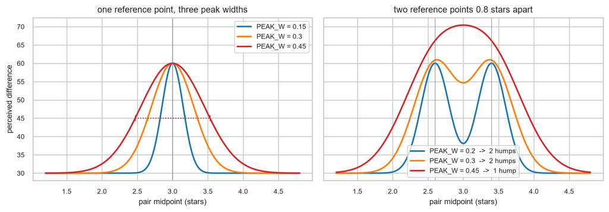

```python
fig, axes = plt.subplots(1, 2, figsize=(10, 3.6), sharey=True)
xs_w = np.linspace(MID_LO, MID_HI, 600)
cols = ['#1f77b4', '#ff7f0e', '#d62728']

for w, col in zip([0.15, 0.30, 0.45], cols):
    axes[0].plot(xs_w, BASELINE + PEAK_AMP * _bump(xs_w, PEAK_CENTRE, w),
                 color=col, lw=1.8, label=f'PEAK_W = {w}')
    half = BASELINE + PEAK_AMP / 2
    axes[0].plot([PEAK_CENTRE - 1.1774 * w, PEAK_CENTRE + 1.1774 * w], [half, half],
                 color=col, lw=1.1, ls=':', marker='|', ms=7)
axes[0].axvline(PEAK_CENTRE, color='grey', lw=.8, alpha=.7)
axes[0].set_title('one reference point, three peak widths', fontsize=10)
axes[0].legend(fontsize=8)

DEMO_W_SEP = 0.8
for w, col in zip([0.20, 0.30, 0.45], cols):
    y = BASELINE + PEAK_AMP * (_bump(xs_w, PEAK_CENTRE - DEMO_W_SEP / 2, w)
                               + _bump(xs_w, PEAK_CENTRE + DEMO_W_SEP / 2, w))
    d = np.diff(y)
    npk = int(np.sum((d[:-1] > 0) & (d[1:] <= 0)))
    axes[1].plot(xs_w, y, color=col, lw=1.8,
                 label=f'PEAK_W = {w}  ->  {npk} hump' + ('s' if npk > 1 else ''))
for L in (PEAK_CENTRE - DEMO_W_SEP / 2, PEAK_CENTRE + DEMO_W_SEP / 2):
    axes[1].axvline(L, color='grey', lw=.8, alpha=.7)
axes[1].set_title(f'two reference points {DEMO_W_SEP} stars apart', fontsize=10)
axes[1].legend(fontsize=8)

for ax in axes:
    ax.set_xlabel('pair midpoint (stars)', fontsize=9)
    ax.tick_params(labelsize=8)
axes[0].set_ylabel('perceived difference', fontsize=9)
plt.tight_layout()
plt.show()
```

The four shapes below are what Layer 1 produces. §7 shows the full pipeline for a single person, from drawing their parameters through to the classifier’s verdict.

Figure 5: The four ground-truth shapes, each shown for one simulated person at 20 midpoints. Dashed line is that person’s true (Layer 1) curve; dots are their actual slider responses (Layer 2). Grey lines mark the two peak locations for the bimodal person. The classifier sees only the dots.

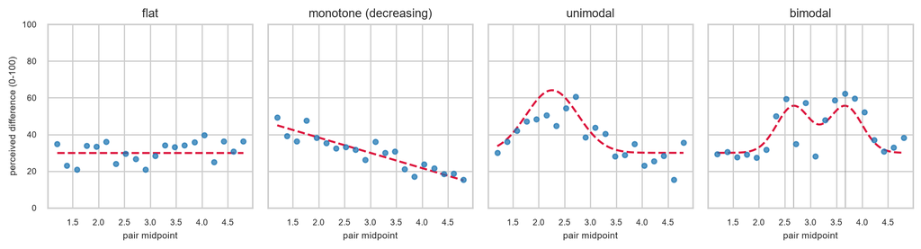

```python
fig, axes = plt.subplots(1, 4, figsize=(11, 3.1), sharey=True)
xs = np.linspace(MID_LO, MID_HI, 300)
for ax, shape in zip(axes, ['flat', 'monotone', 'unimodal', 'bimodal']):
    x, y, p = simulate_person(shape, 20, 1.0)
    ax.scatter(x, y, s=18, alpha=.75, color='#1f77b4', zorder=3)
    ax.plot(xs, np.clip(true_curve(xs, shape, p), 0, SLIDER_MAX),
            color='crimson', ls='--', lw=1.7)
    ax.set_title(shape + (f" ({MONO_DIR})" if shape == 'monotone' else ''), fontsize=10)
    ax.set_xlabel('pair midpoint', fontsize=8)
    ax.tick_params(labelsize=7)
    if shape == 'bimodal':
        for L in (p['loc1'], p['loc2']):
            ax.axvline(L, color='grey', lw=.8, alpha=.6)
axes[0].set_ylabel('perceived difference (0-100)', fontsize=8)
axes[0].set_ylim(0, SLIDER_MAX)
plt.tight_layout()
plt.show()
```

Figure 6: Layer 1’s population distribution of peak locations. Left: where each unimodal person’s single peak sits – most likely at PEAK_CENTRE, less likely further away. Right: the same for bimodal people at a 1.0-star separation, giving two clouds. Truncation keeps every peak on the measured grid.

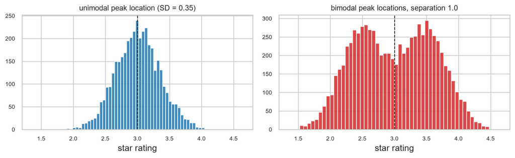

```python
fig, axes = plt.subplots(1, 2, figsize=(10, 3.2), sharex=True)
uni_locs = [draw_person_params('unimodal', 0.0)['loc'] for _ in range(4000)]
axes[0].hist(uni_locs, bins=50, color='#1f77b4', alpha=.85)
axes[0].set_title(f'unimodal peak location (SD = {PEAK_LOC_SD})', fontsize=10)
bi = [draw_person_params('bimodal', 1.0) for _ in range(4000)]
axes[1].hist([p['loc1'] for p in bi] + [p['loc2'] for p in bi],
             bins=50, color='#d62728', alpha=.85)
axes[1].set_title('bimodal peak locations, separation 1.0', fontsize=10)
for ax in axes:
    ax.axvline(PEAK_CENTRE, color='k', ls='--', lw=1)
    ax.set_xlabel('star rating'); ax.set_xlim(MID_LO, MID_HI)
    ax.tick_params(labelsize=8)
plt.tight_layout()
plt.show()
```

### Does a `unimodal` peak at the edge of the scale become `monotone`?

Within the measured window, yes — visually. A bump centred at `MID_HI` shows only its rising half, which reads as a monotone increase. The two are not the same function (a half-bump curves, a `monotone` fit is a straight line), but at realistic noise levels they are not reliably distinguishable.

A monotone curve means **no reference point** — Weber’s law operating with no categorical structure anywhere. It maps to zero.

The competing reading is that it marks a reference point sitting *outside* the measured window, showing only one flank. With midpoints running from `MID_LO` to `MID_HI` that window now spans all but the outermost 0.2 stars at each end of the rating scale, so a reference point would have to sit almost exactly on 1.0 or 5.0 to produce it. The ambiguity is not eliminated — a reference point at the very bottom of the scale still leaves a decaying flank that can read as a slope — but it is confined to a corner of the scale, and the reference points the study is designed to find sit at 2.5 and 3.5, deep in the interior. The simulation therefore generates monotone participants as a straight Weber slope and counts them as zero.

## 5b. Peak width: a non-technical account

This section gives a non-technical account of `PEAK_W`. §5d gives the formal derivation.

### Reference points vary from occasion to occasion

Consider a participant applying the rule **“4 stars and up is good; below that, not”**. Their reference point is at 4.

But people are not machines. On Monday they might accept 3.9. On Tuesday they might hold out for 4.1. Their line drifts around a little from moment to moment.

**How much that line drifts is the whole story.** Some people are very consistent — their line sits within a hair of 4.0 every time. Others are wobbly, landing anywhere between 3.6 and 4.4 depending on mood.

`PEAK_W` is simply **a number describing how much a person’s line wobbles**. If their line typically moves by about 0.3 stars, `PEAK_W` is 0.3. That is all it is. It is a badly chosen name for a simple idea.

### Why reference-point variability produces a hump

Your task shows two products a fixed distance apart and asks how different they feel.

| the pair | what the person thinks | their answer |
| --- | --- | --- |
| 4.5 and 4.7 | both comfortably “good”, same side of the line | small |
| 2.0 and 2.2 | both comfortably “not good”, same side again | small |
| **3.9 and 4.1** | **one is a yes, the other a no** | **large** |

So answers are **large near the line and small away from it**. Plot the answers against where the pair sits on the scale and you get a hump centred on the person’s line. Finding that hump is what this whole document is about.

### Why the hump is smooth rather than a spike

If the line never moved — always exactly 4.0 — then only pairs straddling exactly 4.0 would feel different, and you would get a razor-thin spike.

But the line does move:

- a pair at **3.9 / 4.1** straddles the line almost every time, so it nearly always feels different
- a pair at **3.7 / 3.9** straddles it only on days the line drifts low, so it *sometimes* feels different
- a pair at **3.0 / 3.2** essentially never straddles it

The hump therefore **fades out gradually** as you move away from the line, and how fast it fades is exactly how much the line wobbles. A wobbly person gets a **wide, gentle** hump; a consistent person gets a **narrow, tall** one.

That is where the bell shape comes from. It is not an assumption bolted on for convenience — it falls out of the wobble. §5c checks this by computing the curve exactly, without assuming any bell shape, and comparing.

### The two-reference-point case

Someone with a neutral zone has **two** lines: “below 3 is bad, above 4 is good, in between is neither.” Two lines give two humps, one sitting at each line. That is the `bimodal` shape.

### Why narrow neutral zones are unresolvable

Put those together.

**Two lines far apart** — say 3.0 and 4.5 — give two clearly separate humps with a clear dip between them, and the two are readily distinguished.

**Two lines close together** — say 3.4 and 3.6, each wobbling by 0.3 stars — give humps wide enough to swallow the gap between them. They blur into one blob, and there is **no dip at all**. Not a faint dip needing more data; no dip.

The rule: **the two lines must be roughly twice as far apart as the wobble.**

[output not shown]

Measured neutral zones on a 5-point scale are **0.6-0.8 stars**. If people’s lines wobble by around 0.3, this design sits right on the edge of what it can see — which is why the power numbers in §8 and §13 stay stubborn no matter what is changed about the analysis.

**ImportantThe quantity to estimate in piloting**

**How much does a person’s line wobble?** Everything follows from it, and it has not been measured yet.

Fit the one-hump shape to pilot data and read off the width — it comes out of the fit automatically, as the fourth fitted parameter.

- near **0.15** — this design works comfortably
- near **0.30** — borderline; it works, but barely
- near **0.45** — most real neutral zones are invisible to this task, and the direct-question design in §14 is the way to go

## 5c. Two design parameters

Two natural ideas for improving matters. Both were simulated by `pair_gap_and_repeats.py`, which writes the CSVs read below. **Both turn out to make no useful difference**, and the reasons are worth understanding.

### Effect of the pair gap

It is genuinely a trade, because the gap changes **two** things at once:

- a wider gap gives **more signal** — bigger differences are easier to report consistently, so the hump is taller
- but it also **blurs the hump wider**, because a wide pair straddles the line from further away

```python
import os
if os.path.exists('pair_gap_power.csv'):
    pg = pd.read_csv('pair_gap_power.csv')
    display(pg.pivot_table(
        index=['pair gap', 'hump width', 'hump height (slider pts)'],
        columns='neutral zone', values='Type II (%)'))
else:
    print("Run pair_gap_and_repeats.py first.")
```

Table 9: Type II error (lower is better) for three neutral-zone widths. Both the hump height and the hump width are derived from the wobble model rather than assumed, so widening the gap raises them together. 300 people per cell, so the margin is about +/- 5.7 points.

| pair gap | hump width | neutral zone hump height (slider pts) | 0.600 | 0.700 | 0.800 |
| --- | --- | --- | --- | --- | --- |
| 0.200 | 0.280 | 30.000 | 71.700 | 51.000 | 34.700 |
| 0.300 | 0.292 | 32.200 | 73.000 | 50.300 | 38.300 |
| 0.400 | 0.307 | 35.000 | 73.300 | 60.300 | 33.000 |
| 0.500 | 0.324 | 38.100 | 75.000 | 60.000 | 41.300 |
| 0.600 | 0.344 | 41.400 | 74.700 | 65.000 | 43.700 |

**The two effects cancel almost exactly.** Going from a 0.2 gap to a 0.6 gap raises the hump from 30 to 41 slider points — a real gain in signal — but widens it from 0.28 to 0.34 stars, and the error rates barely move. For a 0.8-star neutral zone the Type II error runs 35, 38, 33, 41, 44 across the whole range, which is inside the margin of error.

**So there is no meaningful difference between 0.3 and 0.4, or indeed between 0.2 and 0.5.** Keep 0.2 if it is already piloted; the choice is not load-bearing. If anything the widest gaps are slightly worse, so do not go above about 0.4.

### Effect of repeated measurement

This is the more interesting question, because it depends on **which kind of noise you are fighting**. There are two, and they are not the same:

|  | what it is | do repeats fix it? |
| --- | --- | --- |
| **Slider noise** | You know what you think, but the slider lands imprecisely | **Yes** — averaging cancels it |
| **Reference-point wobble** | Your line genuinely moves from moment to moment | **No** |

Repeats fix the first and not the second. The reason is that the wobble is not scatter *around* the hump — the wobble is **what gives the hump its shape**. Asking the same pair repeatedly gives you a better measurement of an already blurred quantity. Measuring a blurry photograph more carefully does not sharpen the photograph.

And repeats are not free: at a fixed number of judgments, asking each pair three times means only a third as many distinct midpoints.

```python
if os.path.exists('repeats_power.csv'):
    rp = pd.read_csv('repeats_power.csv')
    display(rp.pivot_table(
        index=['times each pair is asked', 'distinct midpoints',
               'effective noise per midpoint'],
        columns='neutral zone', values=['Type I (%)', 'Type II (%)']))
else:
    print("Run pair_gap_and_repeats.py first.")
```

Table 10: Total judgments held fixed at 45, split different ways. More repeats mean less noise per midpoint but fewer distinct midpoints. 300 people per cell, margin about +/- 5.7 points.

| times each pair is asked | distinct midpoints | neutral zone effective noise per midpoint | Type I (%) 0.600 | Type I (%) 0.800 | Type II (%) 0.600 | Type II (%) 0.800 |
| --- | --- | --- | --- | --- | --- | --- |
| 1 | 45 | 12.000 | 6.700 | 4.700 | 78.000 | 34.700 |
| 2 | 22 | 8.500 | 5.300 | 5.000 | 75.000 | 34.000 |
| 3 | 15 | 6.900 | 5.700 | 5.700 | 71.700 | 34.700 |
| 5 | 9 | 5.400 | 0.300 | 1.000 | 84.300 | 40.700 |

**The trade is a wash up to about three repeats, then it turns bad.** For a 0.8-star zone the Type II error is 35, 34, 35, 41 as repeats go 1, 2, 3, 5 — flat until five repeats leaves only nine distinct midpoints, at which point there are too few points to describe a two-humped curve (the same collapse as the coarse scale in §15).

And repeats do not sharpen the estimate of the wobble either:

```python
if os.path.exists('width_bias.csv'):
    display(pd.read_csv('width_bias.csv').set_index('times each pair is asked'))
else:
    print("Run pair_gap_and_repeats.py first.")
```

Table 11: The fitted hump width, again at a fixed 45-judgment budget. If repeats reduced the wobble, the fitted width would shrink as repeats increase. It does not.

| times each pair is asked | distinct midpoints | true hump width | median fitted width | over-estimate (%) | spread of estimates (SD) |
| --- | --- | --- | --- | --- | --- |
| 1 | 45 | 0.292 | 0.286 | -1.900 | 0.124 |
| 2 | 22 | 0.292 | 0.279 | -4.500 | 0.084 |
| 3 | 15 | 0.292 | 0.290 | -0.600 | 0.137 |
| 5 | 9 | 0.292 | 0.289 | -1.000 | 0.097 |

The fitted width stays within a few percent of the truth at every setting. That is the simulation confirming the conceptual point: **repeats measure the hump more precisely; they do not narrow it.**

### Allocation of a fixed judgment budget

The sharpest version of the question, with the **total judgments held exactly equal** in each comparison so nothing is confounded with effort. `allocation_test.py` runs it at 600 people per cell.

```python
if os.path.exists('allocation_results.csv'):
    al = pd.read_csv('allocation_results.csv')
    display(al[['total judgments', 'neutral zone', 'A: pairs x reps', 'A Type II (%)',
                'B: pairs x reps', 'B Type II (%)', 'Type II: A minus B']]
            .set_index(['total judgments', 'neutral zone']))
else:
    print("Run allocation_test.py first.")
```

Table 12: Equal budgets, split two ways. 600 people per cell, so the margin on any single rate is +/- 4.0 points and on the A-minus-B difference +/- 5.7 points. A negative difference favours repeating pairs; positive favours more unique pairs.

| total judgments | neutral zone | A: pairs x reps | A Type II (%) | B: pairs x reps | B Type II (%) | Type II: A minus B |
| --- | --- | --- | --- | --- | --- | --- |
| 40 | 0.600 | 20 x 2 | 71.800 | 40 x 1 | 73.000 | -1.200 |
|  | 0.700 | 20 x 2 | 59.800 | 40 x 1 | 55.200 | 4.700 |
|  | 0.800 | 20 x 2 | 34.800 | 40 x 1 | 36.200 | -1.300 |
| 44 | 0.600 | 22 x 2 | 71.800 | 44 x 1 | 70.300 | 1.500 |
|  | 0.700 | 22 x 2 | 54.700 | 44 x 1 | 53.200 | 1.500 |
|  | 0.800 | 22 x 2 | 36.300 | 44 x 1 | 30.200 | 6.200 |
| 50 | 0.600 | 25 x 2 | 72.000 | 50 x 1 | 75.000 | -3.000 |
|  | 0.700 | 25 x 2 | 52.500 | 50 x 1 | 50.300 | 2.200 |
|  | 0.800 | 25 x 2 | 30.200 | 50 x 1 | 28.800 | 1.300 |

### Partial replication

A better idea than either extreme: ask **30 distinct pairs, 10 of them twice**, for 40 judgments. `hybrid_design.py` tests it.

```python
if os.path.exists('hybrid_power.csv'):
    hp = pd.read_csv('hybrid_power.csv')
    display(hp.pivot_table(index=['design', 'distinct midpoints'],
                           columns='neutral zone', values='Type II (%)'))
else:
    print("Run hybrid_design.py first.")
```

Table 13: Partial replication at a fixed 40-judgment budget. Cells are Type II error. 500 people per cell, margin about +/- 4.4 points.

| design | neutral zone distinct midpoints | 0.600 | 0.700 | 0.800 |
| --- | --- | --- | --- | --- |
| 20 unique, all 20 repeated | 20 | 73.600 | 52.400 | 36.200 |
| 27 unique, 13 repeated | 27 | 72.400 | 58.600 | 36.400 |
| 30 unique, 10 repeated | 30 | 73.400 | 52.200 | 34.600 |
| 40 unique, none repeated | 40 | 72.200 | 52.000 | 32.800 |

Power is **identical** across every allocation — as §5c has now established three separate ways. So the hybrid costs nothing. The reason to want it is different, and it is a good one.

**Two answers to the same pair differ only by noise**, whatever the true curve looks like. That gives a **model-free estimate of slider noise** — the `SLIDER_SD` that the whole document depends on and that you would otherwise have to infer from residuals, which conflates real noise with the curve model being slightly wrong.

```python
if os.path.exists('hybrid_noise.csv'):
    display(pd.read_csv('hybrid_noise.csv').set_index('design'))
else:
    print("Run hybrid_design.py first.")
```

Table 14: How precisely the repeated pairs recover the slider noise. The true value is 12.0 slider points. Even 10 repeated pairs pins it down to roughly +/- 15%.

| design | repeated pairs | true slider SD | median estimate | 10th pct | 90th pct | typical error (%) |
| --- | --- | --- | --- | --- | --- | --- |
| 30 unique, 10 repeated | 10 | 12.000 | 11.590 | 8.470 | 14.950 | 14.600 |
| 27 unique, 13 repeated | 13 | 12.000 | 11.800 | 8.730 | 14.850 | 13.200 |
| 20 unique, all 20 repeated | 20 | 12.000 | 11.860 | 9.310 | 14.450 | 11.100 |

Ten repeated pairs recover the slider noise to within about 15%, and thirteen to within 13%. Since **`PEAK_AMP / SLIDER_SD` is the master parameter of this whole document** (§4g), getting its denominator cleanly, for free, in the main study rather than a separate pilot, is worth ten judgments.

**WarningA limitation of the replicate-based check**

Replicates should in principle also give a **lack-of-fit test**: if the residuals around the fitted curve are much larger than the noise the replicates imply, the bump shape is wrong for that person. It would be a way to check §5d against real data instead of assuming it.

Tested, it does not work at this noise level:

```python
if os.path.exists('hybrid_lackfit.csv'):
    display(pd.read_csv('hybrid_lackfit.csv').set_index('truth'))
else:
    print("Run hybrid_design.py first.")
```

Table 15: Lack-of-fit test with 10 repeated pairs. If it worked, the triangular-peak row would show a clearly larger ratio and a higher flag rate. It does not.

| truth | median residual SD / replicate SD | % of people flagged (ratio > 1.3) |
| --- | --- | --- |
| Gaussian peaks (model is right) | 1.017 | 11.200 |
| Triangular peaks (model is wrong) | 1.017 | 13.800 |

Both rows give a ratio of 1.02 and flag rates within the margin of each other. This is **consistent with §11.1**, which found that swapping Gaussian peaks for triangular ones barely changes the classification: at `PEAK_AMP / SLIDER_SD` of 2.5 the difference between the two shapes is simply buried in the noise. The test correctly reports no detectable misfit, because there is none to detect. Do not plan on validating the peak shape this way unless your pilot comes back with a much quieter slider.

**TipRecommendation**

**30 distinct pairs with 10 of them repeated, 40 judgments in total.** Power is indistinguishable from any other split, it clears the ~15 distinct-midpoint floor from §15 comfortably, and the ten repeats hand you a clean, model-free measurement of the slider noise you need for every other table in this document.

**TipSummary of §5c**

Neither knob moves the error rates. The pair gap is a wash, repeats are a wash until they start hurting, and splitting a fixed budget between the two is a wash as well.

That is genuinely useful, because it says the levers are elsewhere: the wobble itself (a property of the participants, and a quantity to be estimated), and the choice of task (§14).

But it also means replication is **free**, and free is worth taking when it buys you something. Use the hybrid: **30 distinct pairs, 10 repeated**. You lose no power, you stay well clear of the distinct-midpoint floor, and you walk away with a model-free measurement of the slider noise that every other table here depends on.

## 5d. Derivation of the bump shape

`PEAK_W` is not a free-floating smoothing knob. It falls out of a specific model of what a reference point *is*, and that model tells you what the peak shape should be. This section derives it and checks it.

### Origin of the peak

Suppose a person has one reference point at rating `b`. They do not apply it perfectly: on any given occasion their effective reference-point wobbles a little, so whether a rating counts as “above” is a **probability** rather than a certainty. Write that as a cumulative Gaussian with standard deviation `sigma` — small `sigma` means a crisp reference point, large `sigma` a fuzzy one. This is the standard signal-detection assumption.

Now show them a pair of ratings `delta` apart, centred on midpoint `m`. The two members feel categorically different exactly when they get **different labels**, which has probability

`P(different) = P(above | upper) * P(below | lower) + P(above | lower) * P(below | upper)`

Nothing about that expression is Gaussian-shaped by assumption. So compute it exactly and see what shape comes out.

```python
from scipy.stats import norm, logistic as _logistic

THEORY_SIGMA, THEORY_DELTA = 0.30, 0.20
_tx = np.linspace(MID_LO, MID_HI, 801)
_g1 = lambda x, a, A, m, w: a + A * np.exp(-0.5 * ((x - m) / w) ** 2)
_g2 = lambda x, a, A, m1, m2, w: a + A * (np.exp(-0.5 * ((x - m1) / w) ** 2)
                                          + np.exp(-0.5 * ((x - m2) / w) ** 2))
def _r2(y, yh):
    return 1 - np.sum((y - yh) ** 2) / np.sum((y - y.mean()) ** 2)

_cdf_probit = lambda x, b, s: norm.cdf((x - b) / s)
_cdf_logit  = lambda x, b, s: _logistic.cdf((x - b) / (s * np.sqrt(3) / np.pi))

def _pdiff1(b, s, cdf, delta=THEORY_DELTA):
    lo, hi = cdf(_tx - delta / 2, b, s), cdf(_tx + delta / 2, b, s)
    return hi * (1 - lo) + lo * (1 - hi)

rows = []
for nm, cdf in (("probit (cumulative normal)", _cdf_probit),
                ("logit (logistic)", _cdf_logit)):
    y = _pdiff1(PEAK_CENTRE, THEORY_SIGMA, cdf)
    po, _ = curve_fit(_g1, _tx, y, p0=[0, y.max(), PEAK_CENTRE, THEORY_SIGMA])
    rows.append({'reference-point model': nm,
                 'R^2 of Gaussian bump fit': round(_r2(y, _g1(_tx, *po)), 5),
                 'fitted PEAK_W': round(po[3], 4),
                 "participant's reference-point SD": THEORY_SIGMA,
                 'ratio': round(po[3] / THEORY_SIGMA, 3)})
pd.DataFrame(rows).set_index('reference-point model')
```

Table 16: The exact categorical-difference curve, computed with no bump assumed, then fitted with the Gaussian bump this document uses. R-squared of 1.000 means the Gaussian is not an approximation of convenience – it is what the categorisation model actually produces. Two different reference-point models are tried, to check the result is not an artefact of assuming a normal reference point.

| reference-point model | R^2 of Gaussian bump fit | fitted PEAK_W | participant's reference-point SD | ratio |
| --- | --- | --- | --- | --- |
| probit (cumulative normal) | 1.000 | 0.280 | 0.300 | 0.934 |
| logit (logistic) | 0.998 | 0.267 | 0.300 | 0.891 |

### The two-reference-point model

The `bimodal` shape adds two bumps together. That is a *modelling choice* on top of the derivation above, so it needs its own check. A person with two reference points has **three** categories, and the exact probability that two ratings get different labels is not obviously a sum of two bumps.

```python
def _pdiff2(b1, b2, s, delta=THEORY_DELTA):
    def probs(x):
        p_lo = 1 - norm.cdf((x - b1) / s)
        p_hi = norm.cdf((x - b2) / s)
        return np.vstack([p_lo, np.clip(1 - p_lo - p_hi, 0, 1), p_hi])
    P1, P2 = probs(_tx - delta / 2), probs(_tx + delta / 2)
    return 1 - np.sum(P1 * P2, axis=0)

rows = []
for gap in (0.4, 0.6, 0.8, 1.0, 1.4):
    b1, b2 = PEAK_CENTRE - gap / 2, PEAK_CENTRE + gap / 2
    y = _pdiff2(b1, b2, THEORY_SIGMA)
    try:
        po, _ = curve_fit(_g2, _tx, y, p0=[0, y.max(), b1, b2, THEORY_SIGMA], maxfev=20000)
        rows.append({'true neutral zone': gap,
                     'R^2 of 2-bump fit': round(_r2(y, _g2(_tx, *po)), 5),
                     'fitted PEAK_W': round(po[4], 4),
                     'recovered zone width': round(abs(po[3] - po[2]), 4)})
    except Exception:
        rows.append({'true neutral zone': gap, 'R^2 of 2-bump fit': np.nan,
                     'fitted PEAK_W': np.nan, 'recovered zone width': np.nan})
pd.DataFrame(rows).set_index('true neutral zone')
```

Table 17: Exact three-category difference curve, fitted with the sum-of-two-Gaussians used by the bimodal shape. It also recovers the neutral-zone width: compare the fitted gap against the true gap. Note the upward bias at the narrowest gap, where the two bumps overlap heavily.

| true neutral zone | R^2 of 2-bump fit | fitted PEAK_W | recovered zone width |
| --- | --- | --- | --- |
| 0.400 | 1.000 | 0.273 | 0.459 |
| 0.600 | 1.000 | 0.273 | 0.631 |
| 0.800 | 1.000 | 0.275 | 0.812 |
| 1.000 | 1.000 | 0.278 | 1.002 |
| 1.400 | 1.000 | 0.279 | 1.399 |

Both the shape and the recovered width hold. The only wrinkle is at a 0.4-star zone, where the fitted width comes out about 15% too wide — the two bumps overlap so heavily that the fit cannot fully separate them. That is the same resolution limit as §5, showing up as bias rather than as failure.

### A resolution floor set by reference-point variability

Here is the part that matters for planning. §5 says two reference points are only visible as two humps when they are more than `2 * PEAK_W` apart. We now know `PEAK_W` is roughly the participant’s reference-point SD. So:

**the narrowest neutral zone this task can ever resolve is about twice the fuzziness of the participant’s own reference points.**

That is a fact about the participant, not about your sample size, your classifier, or your rating scale. The one design knob that touches it is the **pair gap `delta`**.

```python
rows = []
_A0 = None
for d in (0.05, 0.10, 0.20, 0.30, 0.50, 0.75, 1.00):
    y = _pdiff1(PEAK_CENTRE, THEORY_SIGMA, _cdf_probit, delta=d)
    po, _ = curve_fit(_g1, _tx, y, p0=[0, y.max(), PEAK_CENTRE, THEORY_SIGMA])
    A, w = po[1], po[3]
    if d == 0.20:
        _A0 = A
    rows.append({'pair gap (delta)': d, 'peak width': round(w, 4),
                 'width / reference-point SD': round(w / THEORY_SIGMA, 3),
                 'narrowest zone resolvable': round(2 * w, 3),
                 'signal (raw)': round(A, 4)})
df_d = pd.DataFrame(rows)
df_d['signal vs delta=0.2'] = (df_d['signal (raw)'] / _A0).round(3)
df_d.drop(columns='signal (raw)').set_index('pair gap (delta)')
```

Table 18: The person is held fixed (reference-point SD 0.30); only the pair gap changes. A wider gap buys signal but broadens the peak, which raises the narrowest neutral zone you can resolve. Signal is expressed relative to a 0.2-star gap.

| pair gap (delta) | peak width | width / reference-point SD | narrowest zone resolvable | signal vs delta=0.2 |
| --- | --- | --- | --- | --- |
| 0.050 | 0.271 | 0.902 | 0.541 | 0.941 |
| 0.100 | 0.273 | 0.908 | 0.545 | 0.953 |
| 0.200 | 0.280 | 0.934 | 0.560 | 1.000 |
| 0.300 | 0.292 | 0.973 | 0.584 | 1.073 |
| 0.500 | 0.324 | 1.080 | 0.648 | 1.271 |
| 0.750 | 0.376 | 1.255 | 0.753 | 1.540 |
| 1.000 | 0.442 | 1.472 | 0.883 | 1.765 |

Three observations follow.

**There is a hard floor.** As the pair gap shrinks, the peak width stops falling at about `0.9 * sigma`. So the narrowest resolvable neutral zone is about `1.8 * sigma` — around **0.54 stars if reference-point SD is 0.30** — and no choice of `delta` gets below it.

**Your current gap of 0.2 is close to optimal, but slightly conservative.** Going from 0.2 to 0.3 or 0.4 raises the resolution limit only from 0.56 to 0.61 stars while increasing the signal by 7-17%. Since `PEAK_AMP / SLIDER_SD` is the master parameter for power, that is probably a good trade.

**TipImplication for the pair gap**

Keep the pair gap at or a little below the reference-point fuzziness: **`delta <= sigma`**. Within that range widening the gap is nearly free signal. Past it you start trading away the resolution you need.

**WarningAssumptions not addressed by this derivation**

Three elements remain assumptions rather than results:

- **The slider is linear in perceived difference.** The derivation gives a *probability* of a categorical difference; the doc treats the 0-100 slider as proportional to it. A compressive or expansive response mapping would distort the peak.
- **The baseline is the non-categorical part.** `BASELINE` stands in for ordinary nominal-distance sensitivity, which exists whether or not a reference point is nearby. Theory says it should carry a Weber tilt (`BASE_SLOPE`), which the config defaults to zero — see §11.6.
- **Peak height and width are drawn independently.** In the derivation they are mildly coupled: a sharper reference point gives a slightly taller peak, about 1.17x going from `sigma = 0.30` down to 0.15. That is smaller than `JITTER_AMP`, so treating them as independent is a minor sin, but it is a sin.

## 6. The classifier

**ImportantConvergence tolerance**

Fitting the 5-parameter `bimodal` model to a person who has **no peak at all** is an *unidentifiable* problem: once the fitted amplitude collapses towards zero, the two peak-location parameters stop affecting the fit entirely, the optimiser has no gradient to follow, and it grinds through its whole evaluation budget before giving up. Measured cost of a single bimodal fit at `maxfev = 20000`:

| True shape of the person | ms per bimodal fit |
| --- | --- |
| `bimodal` | 11 |
| `unimodal` | 118 |
| `monotone` | 187 |
| `flat` | **397** |

Since these fits are only ever compared to one another through their residual sum of squares, there is no need to pin the parameters down to eight decimal places. `FIT_TOL = 1e-4` reproduces every error rate in this document to within the Monte Carlo margin while running about **20 times faster**:

| Setting | ms/person | bimodal correct | uni→bi | mono→bi | flat→bi |
| --- | --- | --- | --- | --- | --- |
| `maxfev=20000`, default tol | 477 | 78.5 | 15.5 | 8.0 | 11.0 |
| `FIT_TOL = 1e-5` | 93 | 78.5 | 13.0 | 6.5 | 11.0 |
| `FIT_TOL = 1e-4` | 22 | 79.0 | 10.5 | 6.0 | 10.0 |

(800 people, 30 judgments, separation 1.0; the Monte Carlo margin on each rate is ±6.9 points.) Tighten `FIT_TOL` if you want to re-verify; expect the render to take roughly twenty times longer.

**TipLower bound on fitted peak width**

```python
SHAPE_ORDER = ['flat', 'monotone', 'unimodal', 'bimodal']
REF_ORDER   = [0, 1, 2]

def n_ref(shape):
    """Curve shape -> number of reference points (the research question)."""
    return N_REFPOINTS[shape]

def m_flat(x, a):              return a + 0 * x
def m_mono(x, a, b):           return a + b * x
def m_uni(x, a, A, m, w):      return a + A * _bump(x, m, w)
def m_bi(x, a, A, m1, m2, w):  return a + A * (_bump(x, m1, w) + _bump(x, m2, w))

# ...and the same two shapes carrying a baseline slope (see 6d)
def m_uni_s(x, a, s, A, m, w):
    return a + s * x + A * _bump(x, m, w)

def m_bi_s(x, a, s, A, m1, m2, w):
    return a + s * x + A * (_bump(x, m1, w) + _bump(x, m2, w))

INF = np.inf

def w_floor(x):
    """Smallest fitted peak half-width we are willing to believe."""
    if not TIE_W_TO_GRID:
        return 0.08
    u = np.unique(x)
    spacing = float(np.min(np.diff(u))) if len(u) > 1 else 0.08
    return max(0.08, 0.75 * spacing)

def candidates(x):
    wlo = w_floor(x)
    if FIT_BASELINE_SLOPE:
        return {
            'flat':     (m_flat, 1, ([-INF], [INF])),
            'monotone': (m_mono, 2, ([-INF, -INF], [INF, INF])),
            'unimodal': (m_uni_s, 5, ([-INF, -INF, 0, MID_LO, wlo],
                                      [INF, INF, INF, MID_HI, 1.2])),
            'bimodal':  (m_bi_s,  6, ([-INF, -INF, 0, MID_LO, MID_LO, wlo],
                                      [INF, INF, INF, MID_HI, MID_HI, 1.2])),
        }
    return {
        'flat':     (m_flat, 1, ([-INF], [INF])),
        'monotone': (m_mono, 2, ([-INF, -INF], [INF, INF])),
        'unimodal': (m_uni,  4, ([-INF, 0, MID_LO, wlo], [INF, INF, MID_HI, 1.2])),
        'bimodal':  (m_bi,   5, ([-INF, 0, MID_LO, MID_LO, wlo],
                                 [INF, INF, MID_HI, MID_HI, 1.2])),
    }

def _peak_slice(name):
    """Where the peak locations sit in popt, which shifts if a slope is fitted."""
    off = 1 if FIT_BASELINE_SLOPE else 0
    return (2 + off, 3 + off) if name == 'unimodal' else (2 + off, 4 + off)

FIT_FAILURES = {}

def _p0(x, y, shape):
    lo, amp = float(np.min(y)), float(np.ptp(y))
    span = MID_HI - MID_LO
    p = {'flat':     [float(np.mean(y))],
         'monotone': [float(np.mean(y)), 0.0],
         'unimodal': [lo, amp, float(np.mean(x)), PEAK_W],
         'bimodal':  [lo, amp, MID_LO + span / 3, MID_LO + 2 * span / 3, PEAK_W]}[shape]
    if FIT_BASELINE_SLOPE and shape in ('unimodal', 'bimodal'):
        p = [p[0], 0.0] + p[1:]          # insert the slope start value
    return p

def info_criterion(rss, n, k, rule=None):
    """Penalised badness-of-fit. Lower is better. `k` = number of parameters."""
    rule = IC_RULE if rule is None else rule
    if n - k - 1 <= 0:
        return np.inf                     # not enough data to identify this shape
    fit = n * np.log(rss / n + 1e-12)     # how badly the shape misses the dots
    if rule == 'AIC':
        return fit + 2 * k
    if rule == 'AICc':
        return fit + 2 * k + (2 * k * (k + 1)) / (n - k - 1)
    if rule == 'BIC':
        return fit + k * np.log(n)        # steeper penalty -> more sceptical
    raise ValueError(rule)

def classify_shape(x, y):
    """Return (best shape label, fitted peak locations)."""
    best, best_ic, best_pk = 'flat', np.inf, ()
    for name, (fn, k, bnds) in candidates(x).items():
        try:
            popt, _ = curve_fit(fn, x, y, p0=_p0(x, y, name), bounds=bnds,
                                maxfev=FIT_MAXFEV, ftol=FIT_TOL, xtol=FIT_TOL)
            ic = info_criterion(float(np.sum((y - fn(x, *popt)) ** 2)), len(x), k)
        except Exception:
            # count failures rather than swallow them: a shape that never fits
            # looks identical to a shape that never wins
            FIT_FAILURES[name] = FIT_FAILURES.get(name, 0) + 1
            continue
        if ic < best_ic:
            best_ic, best = ic, name
            if name in ('unimodal', 'bimodal'):
                a, b = _peak_slice(name)
                best_pk = tuple(np.sort(popt[a:b]))
            else:
                best_pk = ()
    return best, best_pk
```

## 6b. Minimum residual error is not a selection rule

This is the natural first approach, and it fails. The reason is worth setting out, because it motivates everything that follows.

**Residual error can only go down when you add parameters.** The `bimodal` shape contains the `unimodal` shape as a special case (set the two peaks on top of each other), which contains `flat` as a special case (set the amplitude to zero). So a bimodal fit can always match whatever unimodal does, and then use its spare freedom to chase noise a little further. Its error is **mathematically guaranteed** to be less than or equal to the simpler shape’s, whatever the data — even for a person with no structure at all.

Picking the smallest error therefore picks `bimodal` almost every time. It is not a test; it is a foregone conclusion.

The fix is to charge rent for parameters. All three rules below add a penalty to the error, differing only in how steep the penalty is:

- **AIC** adds `2k`, where `k` is the number of parameters
- **AICc** adds a bit more, sized for small samples — the right default when a person contributes 20-45 points
- **BIC** adds `k log n`, which is a **steeper** penalty and so is more sceptical of complicated shapes

```python
SEL_NPT, SEL_SEP, SEL_NPER = 30, 1.0, 300

def fit_all(x, y):
    """Residual sum of squares and parameter count for every candidate shape."""
    out = {}
    for name, (fn, k, bnds) in candidates(x).items():
        try:
            popt, _ = curve_fit(fn, x, y, p0=_p0(x, y, name), bounds=bnds,
                                maxfev=FIT_MAXFEV, ftol=FIT_TOL, xtol=FIT_TOL)
            out[name] = (float(np.sum((y - fn(x, *popt)) ** 2)), k)
        except Exception:
            out[name] = (np.inf, k)
    out['_n'] = len(x)
    return out

def pick(f, rule):
    n, best, best_v = f['_n'], None, np.inf
    for name in SHAPE_ORDER:
        rss, k = f[name]
        if not np.isfinite(rss):
            continue
        ll = n * np.log(rss / n + 1e-12)
        v = {'min RSS (no penalty)': rss,
             'AIC':  ll + 2 * k,
             'AICc': ll + 2 * k + (2 * k * (k + 1)) / (n - k - 1) if n - k - 1 > 0 else np.inf,
             'BIC':  ll + k * np.log(n)}[rule]
        if v < best_v:
            best_v, best = v, name
    return best

sel_fits = {sh: [fit_all(*simulate_person(sh, SEL_NPT, SEL_SEP)[:2])
                 for _ in range(SEL_NPER)] for sh in SHAPE_ORDER}

rows = []
for rule in ['min RSS (no penalty)', 'AIC', 'AICc', 'BIC']:
    r = {'selection rule': rule}
    for sh in SHAPE_ORDER:
        r[f'true {sh}'] = round(100 * np.mean(
            [pick(f, rule) == 'bimodal' for f in sel_fits[sh]]), 1)
    r['overall correct'] = round(100 * np.mean(
        [pick(f, rule) == sh for sh in SHAPE_ORDER for f in sel_fits[sh]]), 1)
    rows.append(r)
print(f"{SEL_NPER} people per true shape, {SEL_NPT} judgments, separation {SEL_SEP}")
print("cells are % CALLED BIMODAL; last column is overall accuracy")
print("")
pd.DataFrame(rows).set_index('selection rule')
```

```
300 people per true shape, 30 judgments, separation 1.0
cells are % CALLED BIMODAL; last column is overall accuracy
```

Table 19: The same fitted curves, scored four different ways. Each cell is the percentage of people called bimodal. A perfect rule would read 0, 0, 0, 100 across the row. ‘Min RSS’ is the smallest-error idea; note that it calls most people with NO structure whatsoever bimodal.

| selection rule | true flat | true monotone | true unimodal | true bimodal | overall correct |
| --- | --- | --- | --- | --- | --- |
| min RSS (no penalty) | 83.000 | 78.300 | 37.700 | 91.300 | 38.400 |
| AIC | 18.300 | 18.300 | 18.300 | 81.700 | 73.800 |
| AICc | 7.300 | 9.700 | 14.700 | 76.000 | 79.200 |
| BIC | 2.300 | 3.300 | 14.000 | 73.700 | 83.600 |

```python
pd.DataFrame([{'candidate shape': nm,
               'parameters (k)': sel_fits['flat'][0][nm][1],
               'mean residual error': round(float(np.mean(
                   [f[nm][0] for f in sel_fits['flat']])), 0)}
              for nm in SHAPE_ORDER]).set_index('candidate shape')
```

Table 20: Mean residual error of each candidate shape, computed only on people whose true curve is FLAT – no peak, no slope, nothing. Error falls steadily as parameters are added, which is why the smallest-error rule is not a test of anything.

| candidate shape | parameters (k) | mean residual error |
| --- | --- | --- |
| flat | 1 | 1048.000 |
| monotone | 2 | 1006.000 |
| unimodal | 5 | 903.000 |
| bimodal | 6 | 825.000 |

**How to read this.** Your binding constraint is false positives — inventing a neutral zone that is not there. Those are the first three columns, and they are the ones to minimise. Detection is the fourth column.

`BIC` is the most conservative of the three penalties and buys a real reduction in false positives for a modest cost in detection. Given that a fabricated “two reference point” subgroup is the failure mode you most want to avoid, **`IC_RULE` is set to `'BIC'`, and every other table in this document is computed under it.** Set it to `'AICc'` or `'AIC'` in the config block and re-render to see the whole document change.

None of these are hypothesis tests. They are *model comparisons*: they always return a winner, and they never tell you whether the winner is any good. That limitation is exactly what §13 addresses.

## 6c. Peak distance as a decision statistic

This approach fails, for a reason that clarifies what the information criterion contributes.

If you fit the two-peak shape you get two locations back, so their distance is always computable. The problem is that **it is always computable**: fit the two-peak shape to someone with one peak and it still returns two numbers. The fit’s natural way to imitate a single hump is to slide the two peaks on top of each other, so most one-peak people give a small distance — but a sizeable minority give a large one, because the fit has chased noise into two separate bumps.

The same objection applies to **trough depth**, and to **distance divided by the fitted peak width**, which is the scale-free version of the same idea.

```python
SHOW_NPER, SHOW_NPT = 300, 45

def _peak_stats(x, y):
    """Distance, trough depth, distance/width, and the BIC gain, for one person."""
    n = len(x)
    fits = candidates(x)
    out = {}
    try:
        fn, k, bnds = fits['bimodal']
        po, _ = curve_fit(fn, x, y, p0=_p0(x, y, 'bimodal'), bounds=bnds,
                          maxfev=FIT_MAXFEV, ftol=FIT_TOL, xtol=FIT_TOL)
        # the bimodal parameter vector is (a, [slope,] A, m1, m2, w)
        a0, b1 = _peak_slice('bimodal')
        b, w = float(po[0]), float(po[-1])
        m1, m2 = sorted(float(v) for v in po[a0:b1])
        rss = float(np.sum((y - fn(x, *po)) ** 2))
        bic_bi = info_criterion(rss, n, k, rule='BIC')
        gg = np.linspace(MID_LO, MID_HI, 1200)
        c = fn(gg, *po)
        top = c.max()
        inner = c[(gg >= m1) & (gg <= m2)]
        trough = inner.min() if len(inner) else top
        out['distance'] = m2 - m1
        out['trough depth'] = 100 * (top - trough) / max(top - b, 1e-9)
        out['distance / width'] = (m2 - m1) / max(w, 1e-9)
    except Exception:
        return None
    try:
        fn2, k2, bnds2 = fits['unimodal']
        po2, _ = curve_fit(fn2, x, y, p0=_p0(x, y, 'unimodal'), bounds=bnds2,
                           maxfev=FIT_MAXFEV, ftol=FIT_TOL, xtol=FIT_TOL)
        bic_uni = info_criterion(float(np.sum((y - fn2(x, *po2)) ** 2)), n, k2, rule='BIC')
    except Exception:
        bic_uni = np.inf
    out['BIC gain'] = bic_uni - bic_bi          # positive favours two peaks
    return out

STAT_KEYS = ['distance', 'trough depth', 'distance / width', 'BIC gain']
uni_stats = [s for s in (_peak_stats(*simulate_person('unimodal', SHOW_NPT, 1.0)[:2])
                         for _ in range(SHOW_NPER)) if s]
thr = {k: np.percentile([u[k] for u in uni_stats], 95) for k in STAT_KEYS}

show_rows = []
for sep in (0.6, 0.8, 1.0, 1.2):
    bi_stats = [s for s in (_peak_stats(*simulate_person('bimodal', SHOW_NPT, sep)[:2])
                            for _ in range(SHOW_NPER)) if s]
    r = {'true separation': sep}
    for k in STAT_KEYS:
        r[k] = round(100 * (1 - np.mean([b[k] > thr[k] for b in bi_stats])), 1)
    show_rows.append(r)
print(f"{SHOW_NPER} people per group, {SHOW_NPT} judgments, Type I fixed at 5%.")
print("thresholds: " + ", ".join(f"{k} > {thr[k]:.2f}" for k in STAT_KEYS))
print("")
pd.DataFrame(show_rows).set_index('true separation')
```

```
300 people per group, 45 judgments, Type I fixed at 5%.
thresholds: distance > 1.95, trough depth > 187.12, distance / width > 10.42, BIC gain > 4.21
```

Table 21: Four ways to decide ‘does this person have two reference points?’. Each statistic’s threshold is set at the 95th percentile of the one-peak group, so all four are held to the SAME 5% Type I error and the comparison is fair. Cells are TYPE II ERROR – lower is better, and power is 100 minus each.

| true separation | distance | trough depth | distance / width | BIC gain |
| --- | --- | --- | --- | --- |
| 0.600 | 94.300 | 98.700 | 100.000 | 72.000 |
| 0.800 | 98.300 | 99.000 | 98.700 | 54.700 |
| 1.000 | 99.000 | 99.000 | 97.700 | 36.300 |
| 1.200 | 100.000 | 99.300 | 95.300 | 19.300 |

**Why BIC does so much better.** A distance of 1.0 stars pinned down tightly and a distance of 1.0 stars barely constrained by the data are completely different pieces of evidence, and the raw distance cannot tell them apart — it reports the estimate and discards the uncertainty. BIC compares how much *better the whole curve fits* once you pay for two extra parameters, so a wobbly, ill-determined pair of peaks earns nothing. It weighs the evidence rather than reporting a point estimate.

**TipEstimand versus test statistic**

- **Peak distance is the *estimand*** — it is the neutral-zone width, the number your paper is about, and the thing to report.
- **BIC is the *test*** — it decides whether that number is supported by this person’s data at all.

Use BIC to decide, then report the distance for the people it selects. Using the distance to decide as well is what fails.

## 7. One population, one confusion matrix

### The generative pipeline for a single participant

The figure below walks a single simulated participant through the whole pipeline, left to right. Every number in this document comes from repeating these four steps a few hundred times and counting how often step 4 gets step 1 right.

Figure 7: How one simulated person is produced and then analysed. Step 1 draws that person’s own parameters from the population. Step 2 turns those into a smooth, noiseless curve – the ground truth, which exists only inside the computer. Step 3 reads the curve at the midpoints you actually test and adds slider noise; this is the only thing a real study would ever see. Step 4 hands those dots to the classifier, which never sees the dashed line.

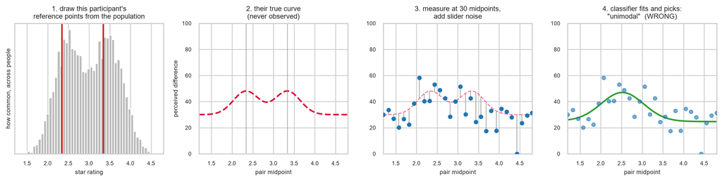

```python
PIPE_SEP, PIPE_NPT = 1.0, 30
_pr = np.random.default_rng(7)

# ---- step 1: this person's parameters, drawn from the population ----------
_draws = [draw_person_params('bimodal', PIPE_SEP) for _ in range(3000)]
_locs = [d['loc1'] for d in _draws] + [d['loc2'] for d in _draws]
p_demo = draw_person_params('bimodal', PIPE_SEP)

fig, ax = plt.subplots(1, 4, figsize=(13, 3.4))

ax[0].hist(_locs, bins=45, color='#bbbbbb')
for L, c in ((p_demo['loc1'], '#d62728'), (p_demo['loc2'], '#d62728')):
    ax[0].axvline(L, color=c, lw=2)
ax[0].set_title("1. draw this participant's\nreference points from the population", fontsize=9)
ax[0].set_xlabel('star rating', fontsize=8)
ax[0].set_ylabel('how common, across people', fontsize=8)
ax[0].set_yticks([])

xs_p = np.linspace(MID_LO, MID_HI, 400)
truth = np.clip(true_curve(xs_p, 'bimodal', p_demo), 0, SLIDER_MAX)
ax[1].plot(xs_p, truth, color='crimson', ls='--', lw=2)
for L in (p_demo['loc1'], p_demo['loc2']):
    ax[1].axvline(L, color='grey', lw=.8, alpha=.7)
ax[1].set_title("2. their true curve\n(never observed)", fontsize=9)

x_d = np.linspace(MID_LO, MID_HI, PIPE_NPT)
y_d = np.clip(true_curve(x_d, 'bimodal', p_demo) + _pr.normal(0, SLIDER_SD, PIPE_NPT),
              0, SLIDER_MAX)
ax[2].plot(xs_p, truth, color='crimson', ls='--', lw=1.2, alpha=.55)
ax[2].vlines(x_d, np.clip(true_curve(x_d, 'bimodal', p_demo), 0, SLIDER_MAX), y_d,
             color='#999999', lw=.8)
ax[2].scatter(x_d, y_d, s=22, color='#1f77b4', zorder=3)
ax[2].set_title(f"3. measure at {PIPE_NPT} midpoints,\nadd slider noise", fontsize=9)

lab, _pk = classify_shape(x_d, y_d)
fn, k, bnds = candidates(x_d)[lab]
try:
    popt, _ = curve_fit(fn, x_d, y_d, p0=_p0(x_d, y_d, lab), bounds=bnds,
                        maxfev=FIT_MAXFEV, ftol=FIT_TOL, xtol=FIT_TOL)
    ax[3].plot(xs_p, fn(xs_p, *popt), color='#2ca02c', lw=2)
except Exception:
    pass
ax[3].scatter(x_d, y_d, s=22, color='#1f77b4', zorder=3, alpha=.6)
ok = 'CORRECT' if lab == 'bimodal' else 'WRONG'
ax[3].set_title(f"4. classifier fits and picks:\n\"{lab}\"  ({ok})", fontsize=9)

for a in ax:
    a.set_xlim(MID_LO, MID_HI)
    a.tick_params(labelsize=7)
for a in ax[1:]:
    a.set_ylim(0, SLIDER_MAX)
    a.set_xlabel('pair midpoint', fontsize=8)
ax[1].set_ylabel('perceived difference', fontsize=8)
plt.tight_layout()
plt.show()
```

Two features of this pipeline are worth making explicit:

- **The dashed red line is the answer sheet.** It exists in step 2 and is used again only in step 4, to mark the classifier right or wrong. The classifier itself is never shown it. In a real study it does not exist at all.
- **Step 3 is the entire real study.** Those blue dots are what a participant actually gives you. Everything this document measures is about how much can be recovered from them.

```python
def classify_population(pop, classifier=classify_shape):
    """Classify every person ONCE and return (true, predicted) pairs."""
    return [(s, classifier(x, y)[0]) for s, x, y in pop]

def confusion_from_pairs(pairs):
    d = pd.DataFrame(pairs, columns=['true', 'pred'])
    cm = pd.crosstab(d['true'], d['pred'], normalize='index') * 100
    return cm.reindex(index=[o for o in SHAPE_ORDER if o in cm.index],
                      columns=[o for o in SHAPE_ORDER if o in cm.columns]).fillna(0)

def confusion(pop, classifier=classify_shape):
    return confusion_from_pairs(classify_population(pop, classifier))

def ref_confusion(pairs):
    """The 3x3 matrix that answers the actual question: 0, 1 or 2 reference points."""
    d = pd.DataFrame([(n_ref(t), n_ref(p)) for t, p in pairs],
                     columns=['true', 'pred'])
    cm = pd.crosstab(d['true'], d['pred'], normalize='index') * 100
    return cm.reindex(index=[r for r in REF_ORDER if r in cm.index],
                      columns=[r for r in REF_ORDER if r in cm.columns]).fillna(0)

def ref_rates(pairs):
    """The two headline numbers, weighted by how common each truth is.

    false positive = P(method says TWO | person really has none or one)
    false negative = P(method says none or one | person really has TWO)
    """
    t = np.array([n_ref(a) for a, _ in pairs])
    p = np.array([n_ref(b) for _, b in pairs])
    not2, is2 = t != 2, t == 2
    fp = 100 * np.mean(p[not2] == 2) if not2.any() else np.nan
    fn = 100 * np.mean(p[is2] != 2) if is2.any() else np.nan
    return fp, fn

DEMO_SEP = 1.0
demo_pop = simulate_population(N_PEOPLE, 20, DEMO_SEP)
cm_demo = confusion(demo_pop)
print(f"{N_PEOPLE} people, 20 judgments each, peaks {DEMO_SEP} stars apart, "
      f"peak/noise = {PEAK_AMP / SLIDER_SD:.2f}, monotone people are {MONO_DIR}")
cm_demo.round(1)
```

```
500 people, 20 judgments each, peaks 1.0 stars apart, peak/noise = 2.50, monotone people are decreasing
```

Table 22: Confusion matrix for a single condition, as row percentages. Rows are the true shape, columns are what the classifier said. The diagonal is correct classification; everything off it is an error.

| pred true | flat | monotone | unimodal | bimodal |
| --- | --- | --- | --- | --- |
| flat | 92.000 | 6.000 | 0.000 | 2.000 |
| monotone | 0.000 | 86.000 | 10.000 | 4.000 |
| unimodal | 7.000 | 0.500 | 79.500 | 13.000 |
| bimodal | 3.500 | 2.500 | 26.500 | 67.500 |

```python
def cell(cm, r, c):
    return float(cm.loc[r, c]) if r in cm.index and c in cm.columns else 0.0

print("Three separate routes to a false 'two reference points' claim:\n")
print(f"  flat     people called bimodal : {cell(cm_demo,'flat','bimodal'):5.1f}%")
print(f"  monotone people called bimodal : {cell(cm_demo,'monotone','bimodal'):5.1f}%")
print(f"  unimodal people called bimodal : {cell(cm_demo,'unimodal','bimodal'):5.1f}%")
print("\nThey pool into the false-positive rate below, weighted by SHAPE_MIX.")
```

```
Three separate routes to a false 'two reference points' claim:

  flat     people called bimodal :   2.0%
  monotone people called bimodal :   4.0%
  unimodal people called bimodal :  13.0%

They pool into the false-positive rate below, weighted by SHAPE_MIX.
```

The table above is the **mechanism**. The table below is the **answer**: it collapses `flat` and `monotone` into “0 reference points”, because those are two different curves that give the same answer to your question.

```python
demo_pairs = classify_population(demo_pop)
rcm_demo = ref_confusion(demo_pairs)
rcm_demo.index.name = 'TRUE reference points'
rcm_demo.columns.name = 'method said'
rcm_demo.round(1)
```

Table 23: The matrix that answers the research question. Rows are how many reference points the person really has; columns are how many the method claimed. Row percentages, so the diagonal is correct and everything else is an error.

| method said TRUE reference points | 0 | 1 | 2 |
| --- | --- | --- | --- |
| 0 | 92.000 | 5.000 | 3.000 |
| 1 | 7.500 | 79.500 | 13.000 |
| 2 | 6.000 | 26.500 | 67.500 |

```python
fp, fn = ref_rates(demo_pairs)
print(f"FALSE POSITIVE : {fp:5.1f}%   method claims TWO reference points")
print(f"                          when the person really has none or one")
print(f"FALSE NEGATIVE : {fn:5.1f}%   method claims none or one")
print(f"                          when the person really has TWO")
print(f"\nBoth are weighted by SHAPE_MIX, so they change if you change how")
print(f"common you think each kind of person is.")
```

```
FALSE POSITIVE :   9.7%   method claims TWO reference points
                          when the person really has none or one
FALSE NEGATIVE :  32.5%   method claims none or one
                          when the person really has TWO

Both are weighted by SHAPE_MIX, so they change if you change how
common you think each kind of person is.
```

## 7b. Illustrative misclassifications

The figure below shows individual misclassified participants drawn from the simulation. The search draws participants until it finds one instance of each kind of error.

In every panel: **blue dots** are the person’s data, the **dashed red line** is their true curve, and the **solid green line** is the shape the classifier chose.

Figure 8: Top row – FALSE POSITIVES: people with no reference point or one, whom the method claims have two. Bottom row – FALSE NEGATIVES: people who really have two, missed. The final panel is a success, for contrast. All at 30 judgments with a 1.0-star neutral zone.

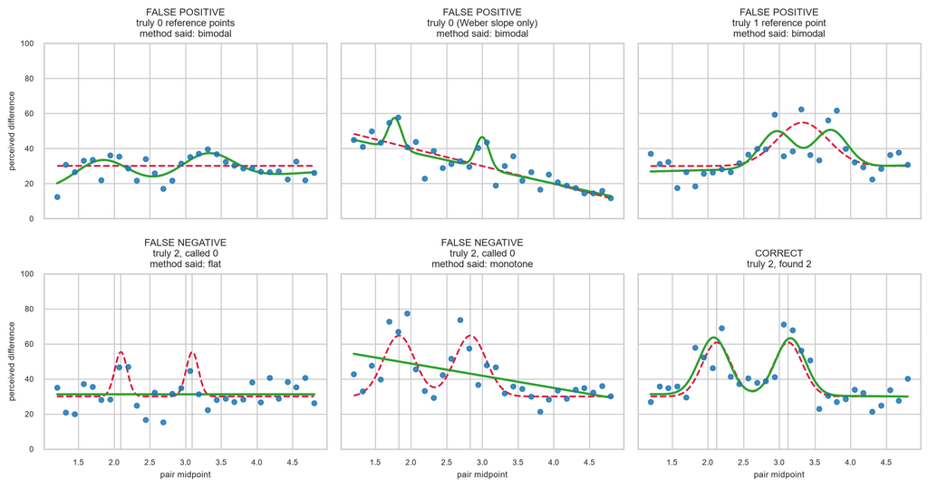

```python
ERR_NPT, ERR_SEP = 30, 1.0

def _fit_curve(x, y, lab, grid):
    fn, k, bnds = candidates(x)[lab]
    try:
        po, _ = curve_fit(fn, x, y, p0=_p0(x, y, lab), bounds=bnds,
                          maxfev=FIT_MAXFEV, ftol=FIT_TOL, xtol=FIT_TOL)
        return fn(grid, *po)
    except Exception:
        return None

def find_case(true_shape, want_pred, tries=4000):
    """Draw people until one is classified as `want_pred`."""
    for _ in range(tries):
        x, y, p = simulate_person(true_shape, ERR_NPT, ERR_SEP)
        lab, _ = classify_shape(x, y)
        if lab == want_pred:
            return x, y, p, lab
    return None

WANTED = [
    ('flat',     'bimodal',  'FALSE POSITIVE\ntruly 0 reference points'),
    ('monotone', 'bimodal',  'FALSE POSITIVE\ntruly 0 (Weber slope only)'),
    ('unimodal', 'bimodal',  'FALSE POSITIVE\ntruly 1 reference point'),
    ('bimodal',  'flat',     'FALSE NEGATIVE\ntruly 2, called 0'),
    ('bimodal',  'monotone', 'FALSE NEGATIVE\ntruly 2, called 0'),
    ('bimodal',  'unimodal', 'FALSE NEGATIVE\ntruly 2, called 1'),
]
grid = np.linspace(MID_LO, MID_HI, 400)
fig, axes = plt.subplots(2, 3, figsize=(12, 6.4), sharex=True, sharey=True)
for ax, (ts, wp, title) in zip(axes.ravel(), WANTED):
    case = find_case(ts, wp)
    if case is None:
        ax.text(.5, .5, f"no {ts} person was\never called {wp}\nin 4000 draws",
                ha='center', va='center', transform=ax.transAxes, fontsize=9)
        ax.set_title(title, fontsize=9)
        continue
    x, y, p, lab = case
    ax.scatter(x, y, s=20, color='#1f77b4', zorder=3, alpha=.85)
    ax.plot(grid, np.clip(true_curve(grid, ts, p), 0, SLIDER_MAX),
            color='crimson', ls='--', lw=1.6)
    fc = _fit_curve(x, y, lab, grid)
    if fc is not None:
        ax.plot(grid, fc, color='#2ca02c', lw=2)
    if ts == 'bimodal':
        for L in (p['loc1'], p['loc2']):
            ax.axvline(L, color='grey', lw=.8, alpha=.5)
    ax.set_title(f"{title}\nmethod said: {lab}", fontsize=9)
    ax.tick_params(labelsize=7)

# one success, for contrast
succ = find_case('bimodal', 'bimodal')
if succ:
    x, y, p, lab = succ
    ax = axes[1, 2]
    ax.clear()
    ax.scatter(x, y, s=20, color='#1f77b4', zorder=3, alpha=.85)
    ax.plot(grid, np.clip(true_curve(grid, 'bimodal', p), 0, SLIDER_MAX),
            color='crimson', ls='--', lw=1.6)
    fc = _fit_curve(x, y, 'bimodal', grid)
    if fc is not None:
        ax.plot(grid, fc, color='#2ca02c', lw=2)
    for L in (p['loc1'], p['loc2']):
        ax.axvline(L, color='grey', lw=.8, alpha=.5)
    ax.set_title("CORRECT\ntruly 2, found 2", fontsize=9)
    ax.tick_params(labelsize=7)

axes[0, 0].set_ylim(0, SLIDER_MAX)
for ax in axes[1]:
    ax.set_xlabel('pair midpoint', fontsize=8)
for ax in axes[:, 0]:
    ax.set_ylabel('perceived difference', fontsize=8)
plt.tight_layout()
plt.show()
```

**Top row.** The fitted curves are plausible descriptions of the data. A false positive is not a failure of the fitting procedure; it is a configuration of noise that resembles two humps. Nothing in the data distinguishes these participants from genuine two-reference-point cases. This is why the false-positive rate cannot be reduced to zero by refining the estimator, and why the complexity penalty in §6b is load-bearing.

**Bottom row.** Missed participants typically have one peak swamped by noise, or the trough between their peaks filled in by a few high dots. Compare the last panel: the successes are visibly two-humped and the failures are not. The information is not present in the data, which is why §13.1 finds that additional judgments do not recover it.

## 8. Sweeping judgments per participant and reference-point separation

The two knobs that genuinely move the error rates: how much data each person gives you, and how far apart their peaks are.

```python
def sweep(n_points_grid, sep_grid, n_people=None, classifier=classify_shape):
    n_people = n_people or N_PEOPLE
    out = []
    for sep in sep_grid:
        for npt in n_points_grid:
            pop = simulate_population(n_people, npt, sep)
            pairs = classify_population(pop, classifier)     # classify once
            cm = confusion_from_pairs(pairs)
            fp, fn = ref_rates(pairs)
            out.append({
                'peak separation': sep, 'judgments per person': npt,
                'n people': n_people,
                'FALSE POSITIVE: said 2, truth 0 or 1 (%)': fp,
                'FALSE NEGATIVE: said 0 or 1, truth 2 (%)': fn,
                'bimodal correct (%)': cell(cm, 'bimodal', 'bimodal'),
                'unimodal called bimodal (%)': cell(cm, 'unimodal', 'bimodal'),
                'monotone called bimodal (%)': cell(cm, 'monotone', 'bimodal'),
                'unimodal correct (%)': cell(cm, 'unimodal', 'unimodal'),
                'monotone correct (%)': cell(cm, 'monotone', 'monotone'),
                'overall accuracy (%)': float(np.mean([t == p for t, p in pairs]) * 100),
            })
    return pd.DataFrame(out)

sw = sweep(N_POINTS, SEP_GRID)
if FIT_FAILURES:
    print("fit failures by shape:", FIT_FAILURES)
_n_bi = N_PEOPLE * SHAPE_MIX['bimodal']
print(f"{N_PEOPLE} people per cell, of whom about {_n_bi:.0f} are truly bimodal.")
print(f"Monte Carlo precision on a bimodal-row cell: about "
      f"+/- {1.96 * np.sqrt(0.25 / _n_bi) * 100:.1f} percentage points.")
```

```
fit failures by shape: {'bimodal': 9}
500 people per cell, of whom about 200 are truly bimodal.
Monte Carlo precision on a bimodal-row cell: about +/- 6.9 percentage points.
```

These first two tables are stated directly in terms of the research question, and pool every route to each kind of error.

**ImportantWhat is held fixed across these rows**

`PEAK_W` is **fixed at its config value throughout this sweep**, so as the reference-point separation changes down a column, the **depth of the dip changes with it**. The rows are not separated only by how far apart the reference points are; they also differ in how pronounced the dip between the humps is:

| separation | dip depth, as % of hump height | two humps at all? |
| --- | --- | --- |
| 0.2 / 0.4 / 0.6 | 0% | no - single hump |
| 0.8 | 20% | yes |
| 1.0 | 50% | yes |
| 1.2 | 73% | yes |

That coupling is not a flaw — the two quantities are not independent (§5a) — but it means a row should be read as “this separation *at this peak width*”, not as separation alone. To vary the dip depth independently, set `PEAK_W` from a target depth using `w_for_trough` in §5a and re-render.

```python
sw.pivot_table(index='peak separation', columns='judgments per person',
               values='FALSE POSITIVE: said 2, truth 0 or 1 (%)').round(1)
```

Table 24: TYPE I ERROR / FALSE POSITIVE (lower is better): percentage of people with NO or ONE reference point whom the method claims have TWO. Rows are peak separation in star units; columns are judgments per person.

| judgments per person peak separation | 20 | 30 | 37 |
| --- | --- | --- | --- |
| 0.600 | 12.700 | 7.300 | 11.700 |
| 0.800 | 12.000 | 6.700 | 10.000 |
| 1.000 | 13.000 | 9.700 | 9.700 |
| 1.200 | 13.000 | 9.000 | 7.300 |

```python
sw.pivot_table(index='peak separation', columns='judgments per person',
               values='FALSE NEGATIVE: said 0 or 1, truth 2 (%)').round(1)
```

Table 25: TYPE II ERROR / FALSE NEGATIVE (lower is better): percentage of people who really have TWO reference points whom the method claims have none or one. Power is 100 minus this. Rows where §5 shows a single-humped true curve are NOT method failures – those people do have two reference points, but this task cannot render them as two peaks. Read those rows as the cost of the design, and see §14 for a design without that floor.

| judgments per person peak separation | 20 | 30 | 37 |
| --- | --- | --- | --- |
| 0.600 | 56.000 | 62.000 | 60.500 |
| 0.800 | 39.000 | 49.500 | 37.000 |
| 1.000 | 29.500 | 28.500 | 26.000 |
| 1.200 | 23.500 | 25.500 | 13.500 |

The remaining tables in this section break those two numbers down by curve shape, which is useful for diagnosing *why* an error rate is what it is.

```python
sw.pivot_table(index='peak separation', columns='judgments per person',
               values='bimodal correct (%)').round(1)
```

Table 26: POWER (higher is better): percentage of truly-bimodal people correctly classified as bimodal. This is 100 minus the Type II error in the table above. Rows are peak separation in star units; columns are judgments per person. Compare against the ‘this task can see it?’ column in §5 – rows marked ‘NO’ there have two reference points but only one hump, so there is no second peak available to find.

| judgments per person peak separation | 20 | 30 | 37 |
| --- | --- | --- | --- |
| 0.600 | 44.000 | 38.000 | 39.500 |
| 0.800 | 61.000 | 50.500 | 63.000 |
| 1.000 | 70.500 | 71.500 | 74.000 |
| 1.200 | 76.500 | 74.500 | 86.500 |

```python
sw.pivot_table(index='peak separation', columns='judgments per person',
               values='unimodal called bimodal (%)').round(1)
```

Table 27: FALSE POSITIVES. Percentage of truly-UNIMODAL people wrongly classified as bimodal – the rate at which the analysis invents a neutral zone that is not there.

| judgments per person peak separation | 20 | 30 | 37 |
| --- | --- | --- | --- |
| 0.600 | 15.000 | 10.000 | 16.000 |
| 0.800 | 15.000 | 8.500 | 12.500 |
| 1.000 | 16.000 | 13.000 | 13.000 |
| 1.200 | 17.500 | 12.500 | 10.500 |

```python
sw.pivot_table(index='peak separation', columns='judgments per person',
               values='monotone called bimodal (%)').round(1)
```

Table 28: The second false-positive route: percentage of truly-MONOTONE people wrongly classified as bimodal. These people have no peak at all, so any bimodal call here is pure noise-chasing.

| judgments per person peak separation | 20 | 30 | 37 |
| --- | --- | --- | --- |
| 0.600 | 10.000 | 4.000 | 4.000 |
| 0.800 | 8.000 | 4.000 | 10.000 |
| 1.000 | 8.000 | 4.000 | 4.000 |
| 1.200 | 6.000 | 4.000 | 2.000 |

Figure 9: Left: correct identification of bimodal people. Right: false bimodal calls among unimodal people. Each line is one peak separation. Dashed lines mark 80% and 10%. Separations below twice the peak width are drawn faint, because there is no second peak there to find.

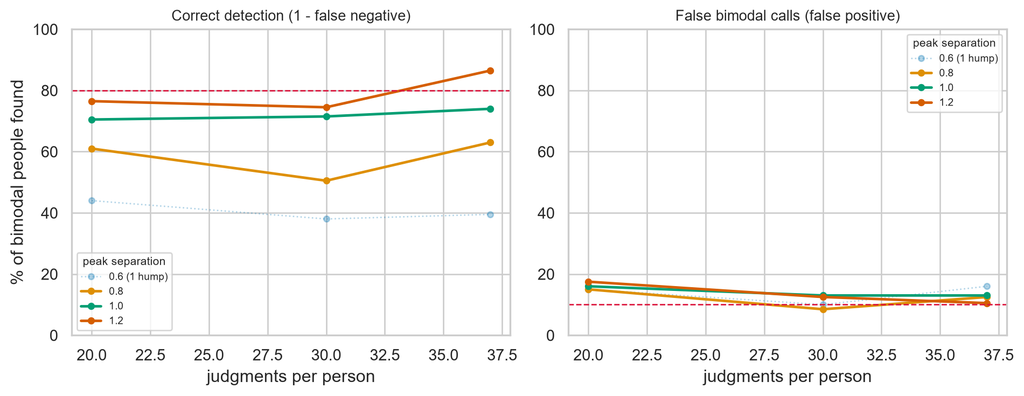

```python
fig, axes = plt.subplots(1, 2, figsize=(10, 4))
for sep, g in sw.groupby('peak separation'):
    g = g.sort_values('judgments per person')
    real = sep > 2 * PEAK_W
    style = dict(marker='o', ms=4, alpha=1.0 if real else 0.30,
                 lw=1.8 if real else 1.0, ls='-' if real else ':')
    lab = f'{sep}' + ('' if real else ' (1 hump)')
    axes[0].plot(g['judgments per person'], g['bimodal correct (%)'], label=lab, **style)
    axes[1].plot(g['judgments per person'], g['unimodal called bimodal (%)'],
                 label=lab, **style)
axes[0].axhline(80, color='crimson', ls='--', lw=1)
axes[0].set_ylabel('% of bimodal people found')
axes[0].set_title('Correct detection (1 - false negative)', fontsize=10)
axes[1].axhline(10, color='crimson', ls='--', lw=1)
axes[1].set_title('False bimodal calls (false positive)', fontsize=10)
for ax in axes:
    ax.set_xlabel('judgments per person')
    ax.set_ylim(0, 100)
    ax.legend(title='peak separation', fontsize=7, title_fontsize=8)
plt.tight_layout()
plt.show()
```

## 8b. Interactive parameter explorer

The tables above fix most settings and vary one or two. This does the opposite: pick any combination and see both error rates at once.

Move the two dropdowns. The **grey band** marks neutral zones narrower than `2 × PEAK_W`, where the two reference points produce a single hump and there is nothing to detect (§5) — a high false-negative rate inside that band is the correct answer, not a failure.

Signal vs noise (PEAK_AMP / SLIDER_SD)  
Judgments per person

**TipNotes on the explorer**

Set the two dropdowns to whatever your pilot says, then read the **blue** line at your measured neutral-zone width — that is the fraction of two-reference-point people you will miss.

Varying **signal vs noise** while holding the other control fixed moves the blue line considerably further than varying judgments-per-person does. This is the result established in §5c and §13.1: reducing measurement noise is more effective than lengthening the survey.

## 9. How many judgments per participant?

```python
req = []
for sep, g in sw.groupby('peak separation'):
    if sep <= 2 * PEAK_W:
        continue
    g = g.sort_values('judgments per person')
    ok = g[g['FALSE NEGATIVE: said 0 or 1, truth 2 (%)'] <= 20]
    if len(ok):
        fa = float(ok['FALSE POSITIVE: said 2, truth 0 or 1 (%)'].iloc[0])
        req.append({'peak separation': sep,
                    'judgments needed': int(ok['judgments per person'].iloc[0]),
                    'false positive there (%)': round(fa, 1),
                    'under 10%?': 'yes' if fa <= 10 else 'NO'})
    else:
        req.append({'peak separation': sep,
                    'judgments needed': f'>{max(N_POINTS)}',
                    'false positive there (%)': np.nan, 'under 10%?': '-'})
pd.DataFrame(req).set_index('peak separation') if req else "No resolvable separations in SEP_GRID."
```

Table 29: Smallest number of judgments per person that gets the FALSE NEGATIVE rate down to 20% (i.e. 80% of two-reference-point people found), and the FALSE POSITIVE rate you pay at that point. Separations with a single-humped true curve are excluded, since there is nothing there to detect.

| peak separation | judgments needed | false positive there (%) | under 10%? |
| --- | --- | --- | --- |
| 0.800 | >37 | NaN | - |
| 1.000 | >37 | NaN | - |
| 1.200 | 37 | 7.300 | yes |

## 10. Effect of the number of participants

The error rates are unaffected by the number of participants. This section documents that result.

The classifier sees one person at a time, so the probability it gets any given person wrong has nothing to do with how many other people are in your study. Running 200, 300, 400 and 500 participants should give you the *same* underlying rates, differing only by chance.

What does change is the **error bar**. With more people you are measuring the same rate more precisely. The last column shows the 95% margin of error on the false-negative row, which shrinks roughly like one over the square root of the number of truly-bimodal people.

```python
N_ROBUST_NPT = 30
rows = []
for sep in [s for s in SEP_GRID if s > 2 * PEAK_W][:2] or SEP_GRID[-1:]:
    for n_ppl in N_PEOPLE_GRID:
        pop = simulate_population(n_ppl, N_ROBUST_NPT, sep)
        pr = classify_population(pop)
        fp_r, fn_r = ref_rates(pr)
        n_bi = n_ppl * SHAPE_MIX['bimodal']
        rows.append({
            'peak separation': sep,
            'n people': n_ppl,
            'false negative (%)': round(fn_r, 1),
            'false positive (%)': round(fp_r, 1),
            'margin of error (+/- pp)': round(1.96 * np.sqrt(.25 / n_bi) * 100, 1),
        })
n_rob = pd.DataFrame(rows).set_index(['peak separation', 'n people'])
print(f"{N_ROBUST_NPT} judgments per person throughout.\n")
n_rob
```

```
30 judgments per person throughout.
```

Table 30: Error rates at four participant counts, holding judgments per person and peak separation fixed. The rates should wander only within the margin of error shown in the last column – if they do, sample size is not affecting them, which is the expected and correct result.

| peak separation | n people | false negative (%) | false positive (%) | margin of error (+/- pp) |
| --- | --- | --- | --- | --- |
| 0.800 | 200 | 32.500 | 12.500 | 11.000 |
|  | 300 | 38.300 | 9.400 | 8.900 |
|  | 400 | 43.800 | 10.800 | 7.700 |
|  | 500 | 42.500 | 9.300 | 6.900 |
| 1.000 | 200 | 23.800 | 12.500 | 11.000 |
|  | 300 | 23.300 | 8.300 | 8.900 |
|  | 400 | 26.200 | 6.700 | 7.700 |
|  | 500 | 27.000 | 8.300 | 6.900 |

Figure 10: The same numbers as a picture. Points are the estimated rates; bars are the 95% margin of error. Flat lines within overlapping bars mean the rate is a property of the method and the per-person data, not of how many participants you run.

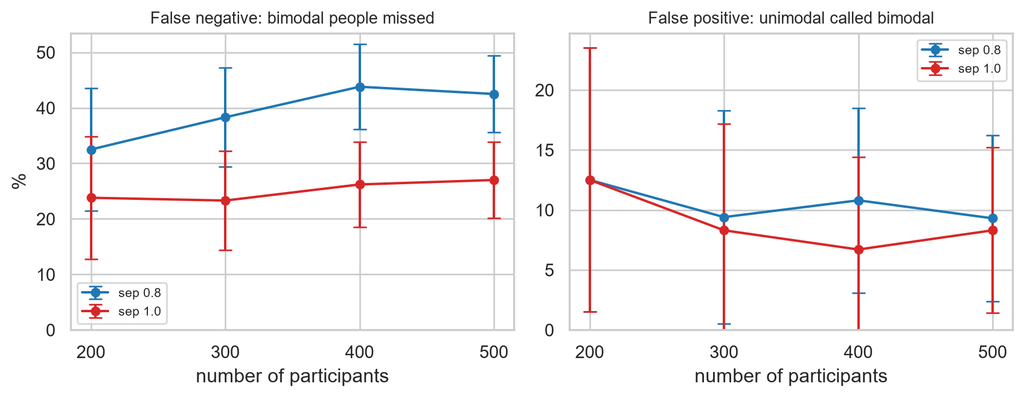

```python
d = n_rob.reset_index()
fig, axes = plt.subplots(1, 2, figsize=(9, 3.6), sharex=True)
for (sep, g), col in zip(d.groupby('peak separation'), ['#1f77b4', '#d62728']):
    for ax, metric in zip(axes, ['false negative (%)', 'false positive (%)']):
        ax.errorbar(g['n people'], g[metric], yerr=g['margin of error (+/- pp)'],
                    marker='o', ms=5, capsize=4, color=col, label=f'sep {sep}')
for ax, t in zip(axes, ['False negative: bimodal people missed',
                        'False positive: unimodal called bimodal']):
    ax.set_title(t, fontsize=10)
    ax.set_xlabel('number of participants')
    ax.set_xticks(N_PEOPLE_GRID)
    ax.set_ylim(bottom=0)
    ax.legend(fontsize=8)
axes[0].set_ylabel('%')
plt.tight_layout()
plt.show()
```

**NoteThe role of sample size**

None of this says 500 participants is pointless. It says participants buy you different things than judgments-per-person do:

- **Judgments per person** buy you a lower error rate on each individual call.
- **Participants** buy you precision on the *population* questions — what fraction of people have a neutral zone, and where the reference points sit on average. Those are the questions your study is actually about.

So set judgments-per-person from §9 and set participants from whatever precision you need on the population estimate.

## 11. Fidelity to the real experiment

Every row below is an assumption baked into Layers 1 and 2. The right-hand column is what happens to the reported error rates if the assumption is wrong.

| # | Assumption in the code | Real experiment? | If it is wrong |
| --- | --- | --- | --- |
| 11.1 | Peaks are exactly bell-shaped, and the classifier fits bell shapes | Unknowable in advance | Tested in §11.1 below — turns out to cost almost nothing |
| 11.2 | Noise is the same size at every x | Probably not - see §11.2 below | Tested: the current model is **conservative** about power |
| 11.3 | A person’s responses are independent of one another | Order effects, drift and fatigue are real | **Biggest risk.** Correlated noise looks exactly like a bump |
| 11.4 | Midpoints are evenly spaced and identical for everyone | True only if your design is fixed, not randomised | Uneven spacing leaves gaps that invite spurious peaks |
| 11.5 | Each midpoint is asked once (`REPS = 1`) | Your call | Repeats average out noise; 2 reps is worth about a 40% noise cut |
| 11.6 | Baseline is flat under the peaks (`BASE_SLOPE = 0`) | Weber’s law says probably not | A tilted baseline makes one peak look taller than the other |
| 11.7 | Slider values are clipped at 0 and 100 | Yes | Only bites if `BASELINE` sits within about 2 SD of an end |

### 11.1 Sensitivity to the assumed peak shape

The check: generate participants whose peaks are **not** bell-shaped — triangular instead — and fit them with the bell-shaped classifier. Any gap between the two rows is the cost of misspecification.

At the defaults the two rows come out **the same to within Monte Carlo error**, which is genuinely reassuring: at this noise level the classifier is deciding *how many humps there are*, not *what precise shape they have*, so getting the peak shape wrong costs almost nothing. Do re-run this if you lower `SLIDER_SD`, because a sharper signal makes the fit fussier about shape.

```python
def _tri(x, m, w):
    """Triangular bump of height 1 -- deliberately NOT the shape we fit."""
    return np.clip(1 - np.abs(x - m) / (2.0 * w), 0, None)

def simulate_person_shape(shape, n_points, sep, bump_fn):
    p = draw_person_params(shape, sep)
    x = np.linspace(MID_LO, MID_HI, n_points)
    if shape == 'unimodal':
        y = _base(x) + p['amp'] * bump_fn(x, p['loc'], PEAK_W)
    elif shape == 'bimodal':
        y = _base(x) + p['amp'] * (bump_fn(x, p['loc1'], PEAK_W)
                                   + bump_fn(x, p['loc2'], PEAK_W))
    else:
        y = true_curve(x, shape, p)
    return x, np.clip(y + rng.normal(0, SLIDER_SD, x.size), 0, SLIDER_MAX)

MIS_SEP, MIS_NPT, MIS_N = 1.0, 30, 300
mis = []
for label, fn in [('gaussian peaks (matches the fit)', _bump),
                  ('triangular peaks (does not)', _tri)]:
    pairs = []
    for shape in ('unimodal', 'bimodal'):
        for _ in range(MIS_N):
            x, y = simulate_person_shape(shape, MIS_NPT, MIS_SEP, fn)
            pairs.append((shape, classify_shape(x, y)[0]))
    cm = confusion_from_pairs(pairs)
    mis.append({'truth generated as': label,
                'bimodal found (%)': round(cell(cm, 'bimodal', 'bimodal'), 1),
                'false bimodal (%)': round(cell(cm, 'unimodal', 'bimodal'), 1)})
print(f"{MIS_N} people per shape, {MIS_NPT} judgments, separation {MIS_SEP}\n")
pd.DataFrame(mis).set_index('truth generated as')
```

```
300 people per shape, 30 judgments, separation 1.0
```

Table 31: Same classifier, two different truths. ‘Gaussian peaks’ matches what the classifier assumes; ‘triangular peaks’ does not. A gap between the rows is what model misspecification would cost you.

| truth generated as | bimodal found (%) | false bimodal (%) |
| --- | --- | --- |
| gaussian peaks (matches the fit) | 63.000 | 10.000 |
| triangular peaks (does not) | 60.700 | 8.300 |

### 11.2 Does the noise model make quiet participants too noisy?

`SLIDER_SD = 12` is added at every midpoint regardless of what the true response there is. For a participant with no structure at all, whose true answer is `BASELINE = 30` everywhere, that puts **95% of their answers between 6 and 54 on a 0-100 slider** — a coefficient of variation of 40% of their own mean. A participant who consistently perceives no difference plausibly parks the slider in a narrow band instead.

Two ratios are conflated here, and they answer different questions:

| ratio | value | what it governs |
| --- | --- | --- |
| `PEAK_AMP / SLIDER_SD` | 2.5 | how detectable a real effect is — discussed throughout |
| `BASELINE / SLIDER_SD` | 2.5 | how noisy a no-structure participant looks |

They are both 2.5 only because `BASELINE` and `PEAK_AMP` were both set to 30. Nothing requires that.

`NOISE_MODEL` offers two alternatives in which quiet participants are quiet. All three are calibrated to the **same SD at the top of a peak**, so signal-to-noise where the signal lives is held fixed and only the quiet end changes.

```python
if os.path.exists('noise_model.csv'):
    display(pd.read_csv('noise_model.csv').set_index(['BASELINE', 'noise model']))
else:
    print("Run noise_model.py to build this table.")
```

Table 32: Three noise models at matched signal-to-noise at the peak. 400 participants per shape per row, 45 judgments, 1.0-star separation, margin about +/- 4.9 points. Produced by noise_model.py.

| BASELINE | noise model | quiet participant's own SD | % responses clipped | Type I (%) | Type II (%) |
| --- | --- | --- | --- | --- | --- |
| 30.000 | constant | 12.000 | 0.900 | 7.000 | 38.000 |
|  | proportional | 6.000 | 0.000 | 3.300 | 20.000 |
|  | floor | 6.700 | 0.000 | 5.500 | 28.200 |
| 15.000 | constant | 12.000 | 9.600 | 7.700 | 38.500 |
|  | proportional | 4.000 | 0.800 | 6.700 | 19.800 |
|  | floor | 5.000 | 1.300 | 5.000 | 23.000 |

**The choice roughly halves the Type II error.** Detection of two-reference-point participants goes from 62% under `constant` to 80% under `proportional`, because the noise shrinks everywhere except at the peaks — including **in the dip between them**, which is exactly where the evidence for two reference points lives. The false-positive rate moves much less, and if anything improves.

**ImportantHow this document reports the choice**

Neither model has been measured, so rather than pick one and hide the other, both are reported and they bracket the answer:

- **`proportional` is the headline.** It is the more plausible of the two: under `constant` a participant who perceives almost no difference still scatters from 0 to 55 on the slider, which the figure in §4d makes hard to defend. It is also what the binary-bias account implies, since within-category responses are compressed toward the floor and compressed responses should be quiet ones.
- **`constant` is the worst case.** It is the pessimistic bound: if the truth is anywhere between the two, the real error rates sit between the two rows, and no result in this document is better than `constant` allows.

So the honest summary of §8’s power tables is **“about 20% Type II if noise scales, no worse than about 38% if it does not”** — and the pilot decides which. Repeating a few pairs at high-response midpoints and a few at low-response ones shows directly whether the scatter shrinks, which settles `NOISE_MODEL` empirically rather than by assumption. That is the same ten repeats §5c already recommends, just placed deliberately.

### 11.3 Correlated responses within a participant

This is the assumption most likely to be violated and least likely to be noticed. The code adds a fresh, independent random number to every dot. A real participant drifts: if they are running high on trial 7 they are probably still running high on trial 8. Drift produces smooth wiggles in the data that are **indistinguishable from a real bump** by any method that only sees one person’s dots.

```python
def simulate_person_ar(shape, n_points, sep, rho):
    """Same person, same total noise, but errors drift with correlation rho."""
    p = draw_person_params(shape, sep)
    x = np.linspace(MID_LO, MID_HI, n_points)
    e = np.empty(n_points)
    e[0] = rng.normal(0, SLIDER_SD)
    s = SLIDER_SD * np.sqrt(1 - rho ** 2)       # keeps the marginal SD at SLIDER_SD
    for i in range(1, n_points):
        e[i] = rho * e[i - 1] + rng.normal(0, s)
    return x, np.clip(true_curve(x, shape, p) + e, 0, SLIDER_MAX)

corr = []
for rho in (0.0, 0.3, 0.6):
    pairs = []
    for shape in ('unimodal', 'bimodal', 'flat'):
        for _ in range(250):
            x, y = simulate_person_ar(shape, MIS_NPT, MIS_SEP, rho)
            pairs.append((shape, classify_shape(x, y)[0]))
    cm = confusion_from_pairs(pairs)
    corr.append({'trial-to-trial correlation': rho,
                 'bimodal found (%)': round(cell(cm, 'bimodal', 'bimodal'), 1),
                 'unimodal called bimodal (%)': round(cell(cm, 'unimodal', 'bimodal'), 1),
                 'FLAT called bimodal (%)': round(cell(cm, 'flat', 'bimodal'), 1)})
pd.DataFrame(corr).set_index('trial-to-trial correlation')
```

Table 33: Independent noise (what the file assumes) against drifting noise of the SAME total size. Nothing about the person changed – only how their errors are correlated across trials.

| trial-to-trial correlation | bimodal found (%) | unimodal called bimodal (%) | FLAT called bimodal (%) |
| --- | --- | --- | --- |
| 0.000 | 55.200 | 9.200 | 1.600 |
| 0.300 | 60.800 | 23.200 | 9.600 |
| 0.600 | 69.200 | 28.400 | 30.000 |

The `flat` row is the one to read. Those people have **no structure whatsoever** in their true curve. Every bimodal call in that row is the method inventing a neutral zone out of pure noise. If that number climbs as correlation rises, your real-world false-positive rate is higher than the headline tables say.

The practical defence is design, not analysis: **randomise the order** in which midpoints are presented for each participant. Drift then smears across the x-axis instead of pooling into a fake bump.

## 12. Summary of findings

```python
resolvable = [s for s in SEP_GRID if s > 2 * PEAK_W]
print(f"Peak half-width is {PEAK_W}, so separations at or below {2*PEAK_W:.1f} stars "
      f"are single-humped curves with nothing to detect.")
print(f"Resolvable separations in this run: {resolvable}\n")
print("At the largest number of judgments in the sweep:\n")
print(f"  {'sep':>5}{'FALSE POS (said 2, truth 0/1)':>32}"
      f"{'FALSE NEG (said 0/1, truth 2)':>32}")
for sep, g in sw.groupby('peak separation'):
    b = g.sort_values('judgments per person').iloc[-1]
    tag = '' if sep > 2 * PEAK_W else '   [true curve has ONE hump]'
    print(f"  {sep:>5}{b['FALSE POSITIVE: said 2, truth 0 or 1 (%)']:>32.1f}"
          f"{b['FALSE NEGATIVE: said 0 or 1, truth 2 (%)']:>32.1f}{tag}")
```

```
Peak half-width is 0.3, so separations at or below 0.6 stars are single-humped curves with nothing to detect.
Resolvable separations in this run: [0.8, 1.0, 1.2]

At the largest number of judgments in the sweep:

    sep   FALSE POS (said 2, truth 0/1)   FALSE NEG (said 0/1, truth 2)
    0.6                            11.7                            60.5   [true curve has ONE hump]
    0.8                            10.0                            37.0
    1.0                             9.7                            26.0
    1.2                             7.3                            13.5
```

Four things these tables are telling you.

**Peak separation matters more than anything else, and below `2 * PEAK_W` the question is malformed.** Peaks closer together than twice the peak width are not two peaks; they are one. No amount of data recovers a structure that is not there. Decide what separation you actually care about detecting before reading any other table.

**Participants do not change the error rates.** §10 shows the rates flat across 200 to 500 people. Judgments per person is the knob that moves them.

**The false-positive rate is the binding constraint, and more data does not fix it.** The bimodal shape always has spare flexibility to chase noise, so some genuinely unimodal people will always be labelled bimodal. Across several hundred participants that is enough to manufacture a “two reference point” subgroup that does not exist.

**So classify with a caveat, not a verdict.** Two protections, both of which use the fact that you have hundreds of people:

- **Report the fitted neutral-zone width alongside the label**, rather than only the label. Note from §6c that this is a *description*, not a second test — thresholding the width or the trough depth is markedly worse than BIC at deciding who has two reference points.
- **Fit all participants jointly in a hierarchical model**, letting peak locations and amplitudes come from population-level distributions. Shrinkage is exactly what suppresses false bimodal calls.

Then do the thing you actually want: **among people classified bimodal, ask where their peaks fall** and check those against that person’s separately elicited reference points. `classify_shape` already returns the fitted locations as its second value.

## 13. Nonparametric alternatives

If assuming a bell-shaped peak is a concern, here is a distribution-free version: fit the best **unimodal regression** — which assumes only “rises then falls”, no functional form — then bootstrap its residuals to get the null distribution of the peak count. Unlike Hartigan’s dip, it is calibrated for *your* design and sample size.

**WarningThe smoothing bandwidth controls power, not the false-positive rate**

The bootstrap generates its null using the same smoother, so any tendency of a narrow bandwidth to see spurious peaks appears in the null too and cancels out. Measured across bandwidths from 0.03 to 0.18 at peak/noise 4:

- **false-positive rate stayed at 0-3% throughout** — that is what the calibration buys, and it is robust to how you smooth
- **detection swung from 0% to 37%**, peaking sharply at `frac = 0.06`

The smoother family barely matters (gaussian 35%, local-linear 37%) but a plain moving average is much worse (7%). `frac = 0.06` is near optimal *for peaks 0.9 stars apart* — the bandwidth must sit at roughly a quarter of the separation you want to resolve; changing `PEAK_SEP` requires retuning `frac`, or power collapses silently.

```python
def unimodal_regression(y):
    """Best rises-then-falls fit. Nonparametric."""
    n = len(y); idx = np.arange(n)
    inc, dec = IsotonicRegression(increasing=True), IsotonicRegression(increasing=False)
    best, best_rss = None, np.inf
    for m in range(n):
        f = np.empty(n)
        f[:m + 1] = inc.fit_transform(idx[:m + 1], y[:m + 1])
        if m < n - 1:
            f[m:] = dec.fit_transform(idx[m:], y[m:])
        rss = float(np.sum((y - f) ** 2))
        if rss < best_rss:
            best_rss, best = rss, f
    return best

def _smooth(x, y, frac):
    # The bandwidth must sit well BELOW the peak separation you want to resolve.
    # At frac=0.18 the smoother merged peaks 0.9 stars apart even with zero noise.
    h = frac * (x.max() - x.min())
    K = np.exp(-0.5 * ((x[:, None] - x[None, :]) / h) ** 2)
    return (K @ y) / K.sum(axis=1)

def count_peaks(x, y, frac=0.06, prom_frac=0.10):
    s = _smooth(x, y, frac)
    r = float(np.ptp(s))
    return 0 if r <= 0 else len(find_peaks(s, prominence=prom_frac * r)[0])

def classify_nonparametric(x, y, B=99, alpha=.05, frac=0.06, prom_frac=0.10):
    """Bootstrap-calibrated peak count."""
    obs = count_peaks(x, y, frac, prom_frac)
    if obs < 2:
        return 'unimodal', ()            # short-circuit: the p-value cannot rescue it
    fit = unimodal_regression(y)
    resid = y - fit
    resid = resid - resid.mean()
    null = np.array([count_peaks(x, fit + rng.choice(resid, len(y), replace=True),
                                 frac, prom_frac)
                     for _ in range(B)])
    p = (1 + np.sum(null >= obs)) / (B + 1)
    return ('bimodal' if p < alpha else 'unimodal'), ()

if RUN_NONPARAMETRIC:
    np_rows = []
    for npt in [30, 60, 90]:
        pop = simulate_population(80, npt, 1.0,
                                  mix={'unimodal': 0.5, 'bimodal': 0.5})
        cm = confusion(pop, classify_nonparametric)
        np_rows.append({'judgments per person': npt,
                        'bimodal correct (%)': cell(cm, 'bimodal', 'bimodal'),
                        'unimodal called bimodal (%)': cell(cm, 'unimodal', 'bimodal')})
    display(pd.DataFrame(np_rows).set_index('judgments per person').round(1))
else:
    print("RUN_NONPARAMETRIC is False (it runs a bootstrap per simulated person).")
    print("Set it True in the config block to reproduce these reference values,")
    print("measured separately with peaks 0.9 stars apart:\n")
    print("  peak/noise = 4:  60 judgments -> 33% found;  80 -> 48%;  120 -> 71%")
    print("  peak/noise = 6:  60 judgments -> 76% found;  80 -> 89%;  120 -> 96%")
    print("  false-bimodal rate throughout: 0-1%")
```

```
RUN_NONPARAMETRIC is False (it runs a bootstrap per simulated person).
Set it True in the config block to reproduce these reference values,
measured separately with peaks 0.9 stars apart:

  peak/noise = 4:  60 judgments -> 33% found;  80 -> 48%;  120 -> 71%
  peak/noise = 6:  60 judgments -> 76% found;  80 -> 89%;  120 -> 96%
  false-bimodal rate throughout: 0-1%
```

### 13.1 Sensitivity of the nonparametric test to sample size

The statistic in `classify_nonparametric` is an **integer** — a count of peaks. Integer statistics give lumpy, conservative p-values and throw away information: a barely-there second peak and an obvious one both score “2”. Replacing it with a **continuous** statistic — the prominence of the second peak as a fraction of the curve’s range — while changing nothing else lifts detection enormously.

That continuous version runs a Type I error of 7-13% rather than the nominal 5%, because the isotonic null **overfits**: its residuals come out too small, so the bootstrap null is too tight. Rescaling residuals by the fit’s effective degrees of freedom (“corrected” below) fixes the calibration at a cost in detection.

The sweep below was run separately by `np_sweep_nonparametric.py` (about 12 minutes) and its output is in `np_sweep_results.csv`. Re-run that script if you change any Layer 1 parameter.

```python
import os
if os.path.exists('np_sweep_results.csv'):
    npsw = pd.read_csv('np_sweep_results.csv')
    t = npsw.pivot_table(index=['peak/noise', 'separation', 'judgments'],
                         columns='version', values=['Type I (%)', 'Type II (%)'])
    t = t[[('Type I (%)', 'uncorrected'), ('Type II (%)', 'uncorrected'),
           ('Type I (%)', 'corrected'),   ('Type II (%)', 'corrected')]]
    t.columns = ['Type I uncorr', 'Type II uncorr', 'Type I corr', 'Type II corr']
    display(t)
else:
    print("np_sweep_results.csv not found - run np_sweep_nonparametric.py first.")
```

Table 34: Type I and Type II error of the CONTINUOUS nonparametric test at 40, 45 and 50 judgments per person. 200 simulated people per cell, so the margin of error is +/- 3.0 points on Type I and +/- 6.9 on Type II. Read across a row: extra judgments do almost nothing. Read down: separation and signal strength dominate.

| peak/noise | separation | judgments | Type I uncorr | Type II uncorr | Type I corr | Type II corr |
| --- | --- | --- | --- | --- | --- | --- |
| 2.500 | 0.800 | 40 | 8.500 | 84.500 | 4.000 | 93.000 |
|  |  | 45 | 7.500 | 84.000 | 4.500 | 90.500 |
|  |  | 50 | 7.000 | 83.000 | 6.000 | 89.500 |
|  | 1.000 | 40 | 8.500 | 50.500 | 2.500 | 65.000 |
|  |  | 45 | 8.500 | 41.500 | 6.000 | 55.500 |
|  |  | 50 | 7.000 | 43.500 | 4.000 | 49.000 |
| 4.000 | 0.800 | 40 | 8.000 | 76.500 | 2.500 | 83.500 |
|  |  | 45 | 8.500 | 68.000 | 4.000 | 82.000 |
|  |  | 50 | 9.500 | 73.000 | 3.000 | 83.500 |
|  | 1.000 | 40 | 11.500 | 18.000 | 8.500 | 30.500 |
|  |  | 45 | 11.000 | 18.000 | 4.500 | 31.500 |
|  |  | 50 | 13.000 | 16.500 | 3.000 | 19.000 |

**Two things to take from this.**

*Extra judgments buy nothing in this range.* At peak/noise 4 and separation 1.0 the Type II error goes 30.5 → 31.5 → 19.0 as you move from 40 to 50 judgments, which is inside the error bars. You are on a plateau. Separation and signal strength swamp sample size: dropping separation from 1.0 to 0.8 stars pushes Type II from 19% to 83%.

*And it still loses to BIC.* At the default signal strength, with separation 1.0:

| method | judgments per person | Type I | Type II |
| --- | --- | --- | --- |
| **BIC** (§6b) | **30** | **5.0%** | **27%** |
| nonparametric, corrected | 50 | 4.0% | 49% |

**NoteRelevance of this section**

Because it tells you where your leverage is. The plateau means lengthening the survey is a dead end. The columns say the two things that matter are **peak separation** (a fact about people, which §5 shows you cannot measure below `2 * PEAK_W`) and **`PEAK_AMP / SLIDER_SD`** (partly under your control).

Moving from the 2.5 row to the 4.0 row is worth far more than twenty extra judgments — and unlike separation, you can buy it: quieter measurement through repeated ratings per midpoint, a practice block, or a forced-choice response format instead of a slider.

### 13.2 A nonparametric curve fit, then the dip test

The failure of the dip test in §13 is **grid coarseness**: at 20-45 midpoints the pseudo-sample is a handful of values repeated many times, and ties drive the statistic. Fitting a smooth curve first removes that obstacle, because the fit can be evaluated on an arbitrarily dense grid. The sequence is: loess fit -> evaluate at 400 points -> convert to a pseudo-sample -> Hartigan’s dip statistic -> threshold.

This works, in the sense that the ties problem genuinely disappears. On noiseless curves the statistic separates cleanly (D = 0.005 for one peak against 0.011 for two). The question is whether it survives noise.

`method_shootout.py` compares five decision statistics on identical data. Each threshold is set at the 95th percentile of the one-peak group, so **all five are held to the same 5% Type I error** and the comparison is fair.

```python
if os.path.exists('method_shootout.csv'):
    _ms = pd.read_csv('method_shootout.csv')
    display(_ms.pivot_table(index='method', columns='separation',
                            values='Type II (%)'))
else:
    print("Run method_shootout.py to build this table.")
```

Table 35: Type II error (lower is better) for five ways of deciding one peak or two, all at a 5% Type I error, 45 judgments per person, 400 people per cell (margin about +/- 4.9 points). Produced by method_shootout.py.

| separation method | 0.800 | 1.000 | 1.200 |
| --- | --- | --- | --- |
| BIC (parametric) | 38.700 | 10.000 | 4.700 |
| loess + dip statistic | 99.000 | 85.800 | 42.000 |
| loess trough depth | 92.200 | 69.200 | 38.700 |
| peak count | 98.500 | 97.000 | 98.200 |
| second-peak prominence | 95.200 | 53.800 | 17.500 |

**The parametric fit wins by a wide margin**, and the ordering among the nonparametric options is informative in itself:

1. **BIC on the parametric fit** — 10% Type II at a 1.0-star neutral zone
2. **Second-peak prominence** on a smoothed curve — 54%
3. **Trough depth** of the loess fit — 69%
4. **Loess then dip statistic** — 86%
5. **Peak count** — 97%

Two things follow. First, the loess-then-dip route is a **legitimate** method, and it is far better than applying dip to the raw data, which §13 shows is useless. The density trick does what it is supposed to. Second, it is still weaker than every alternative except naive peak counting.

The reason is that the dip statistic compresses the entire curve into a single number describing how *concentrated* it is. That discards the information that matters here — whether there are two humps, and where. Measuring the trough directly (row 3) beats it, and measuring the second peak’s prominence (row 2) beats that, precisely because each is a less lossy summary of the same curve.

**NoteWhat the ranking says about assumptions**

The methods are ordered by how much structure they assume, and the ordering of their power is the reverse. Assuming a functional form is not cost-free — §11.1 measures what it costs when the form is wrong, and finds it small at this noise level — but it buys a great deal of power, because the alternative is to summarise the curve into a statistic that throws most of it away.

The nonparametric routes are worth keeping as a **robustness check**: if BIC and second-peak prominence agree on a participant, the call does not rest on the Gaussian assumption. They are not worth adopting as the primary analysis.

## 14. An alternative experimental design

Every number so far says the same thing: **80% detection is hard to reach in this design, and adding judgments does not get you there.** That is worth taking seriously as a signal about the design rather than about the analysis.

### Why the present design has limited power

The current task measures a **difference** between two nearby ratings. But a discriminability peak is not the reference point itself — it is the *steepest part* of the underlying categorisation. In other words, this design measures something like the **derivative** of the thing you actually care about, and then asks the classifier to recover the original from it.

Recovering a function from noisy measurements of its slope is much harder than measuring the function directly. That is the whole difficulty, and it also explains the §5 resolution floor: two peaks closer than `2 * PEAK_W` merge into one hump, so the design is **structurally blind** below that separation, no matter how much data you collect.

### Direct estimation of the reference points

Ask two binary questions about a **single** rating, rather than a slider about a pair:

- *“Would you consider buying this?”* — the answer flips at the **lower** reference point
- *“Would you avoid this?”* — the answer flips at the **upper** reference point

Each question gives a standard psychometric function, and its flip point is a reference point estimated directly. Then:

- **one reference point** ⟺ the two flip points **coincide**
- **two reference points** ⟺ they are separated, and the gap *is* the neutral zone

This is no longer a question about humps. It is a question about whether two thresholds differ, which is among the best-understood measurements in psychophysics.

```python
from scipy.optimize import minimize

PSY_SLOPE, PSY_LAPSE = 0.18, 0.03    # reference-point fuzziness (stars) and misclick rate

def _logi(x, m, sl):
    z = np.clip(-(x - m) / max(sl, 1e-6), -500, 500)   # clip to avoid exp overflow
    return 1 / (1 + np.exp(z))

def simB(shape, n, sep, slope=None):
    """n total judgments, split evenly between the two questions."""
    slope = PSY_SLOPE if slope is None else slope
    c = PEAK_CENTRE + rng.normal(0, PEAK_LOC_SD)
    t_lo, t_hi = (c, c) if shape == 'unimodal' else (c - sep / 2, c + sep / 2)
    m = n // 2
    x = np.linspace(MID_LO, MID_HI, m)
    p_con = PSY_LAPSE + (1 - 2 * PSY_LAPSE) * _logi(x, t_lo, slope)
    p_avo = PSY_LAPSE + (1 - 2 * PSY_LAPSE) * (1 - _logi(x, t_hi, slope))
    return x, (rng.random(m) < p_con).astype(int), (rng.random(m) < p_avo).astype(int)

def _nllB(x, rc, ra, t_lo, t_hi, sl):
    pc = np.clip(PSY_LAPSE + (1 - 2 * PSY_LAPSE) * _logi(x, t_lo, sl), 1e-9, 1 - 1e-9)
    pa = np.clip(PSY_LAPSE + (1 - 2 * PSY_LAPSE) * (1 - _logi(x, t_hi, sl)), 1e-9, 1 - 1e-9)
    return -(np.sum(rc * np.log(pc) + (1 - rc) * np.log(1 - pc))
             + np.sum(ra * np.log(pa) + (1 - ra) * np.log(1 - pa)))

def testB(x, rc, ra):
    """BIC: do the two thresholds differ, or are they one and the same?"""
    n = 2 * len(x)
    one = minimize(lambda q: _nllB(x, rc, ra, q[0], q[0], q[1]),
                   [PEAK_CENTRE, PSY_SLOPE], method='Nelder-Mead',
                   options={'maxiter': 3000, 'fatol': 1e-6})
    two = minimize(lambda q: _nllB(x, rc, ra, min(q[0], q[1]), max(q[0], q[1]), q[2]),
                   [PEAK_CENTRE - .3, PEAK_CENTRE + .3, PSY_SLOPE],
                   method='Nelder-Mead', options={'maxiter': 5000, 'fatol': 1e-6})
    return (2 * two.fun + 3 * np.log(n)) < (2 * one.fun + 2 * np.log(n))

def testA(x, y):
    """Design A, restricted to the same two-way question for a fair comparison."""
    sc = {}
    for nm in ('unimodal', 'bimodal'):
        fn, k, bnds = candidates(x)[nm]
        try:
            po, _ = curve_fit(fn, x, y, p0=_p0(x, y, nm), bounds=bnds,
                              maxfev=FIT_MAXFEV, ftol=FIT_TOL, xtol=FIT_TOL)
            sc[nm] = info_criterion(float(np.sum((y - fn(x, *po)) ** 2)), len(x), k)
        except Exception:
            sc[nm] = np.inf
    return sc['bimodal'] < sc['unimodal']

DES_NPER = 200
des_rows = []
for sep in (0.4, 0.8, 1.0):
    for npt in (30, 45):
        fa = np.mean([testA(*simulate_person('unimodal', npt, sep)[:2])
                      for _ in range(DES_NPER)])
        pa = np.mean([testA(*simulate_person('bimodal', npt, sep)[:2])
                      for _ in range(DES_NPER)])
        fb = np.mean([testB(*simB('unimodal', npt, sep)) for _ in range(DES_NPER)])
        pb = np.mean([testB(*simB('bimodal', npt, sep)) for _ in range(DES_NPER)])
        des_rows.append({'separation': sep, 'judgments': npt,
                         'A Type I (%)': round(100 * fa, 1),
                         'A Type II (%)': round(100 * (1 - pa), 1),
                         'B Type I (%)': round(100 * fb, 1),
                         'B Type II (%)': round(100 * (1 - pb), 1)})
pd.DataFrame(des_rows).set_index(['separation', 'judgments'])
```

Table 36: Head-to-head at equal total judgments per person, both scored with BIC. Design A is the current slider-on-pairs task; Design B is the two-binary-questions task. 200 simulated people per cell, so the margin of error is about +/- 6.9 points.

| separation | judgments | A Type I (%) | A Type II (%) | B Type I (%) | B Type II (%) |
| --- | --- | --- | --- | --- | --- |
| 0.400 | 30 | 13.000 | 84.500 | 6.500 | 67.000 |
|  | 45 | 11.500 | 84.500 | 8.000 | 58.500 |
| 0.800 | 30 | 11.500 | 38.500 | 9.000 | 32.000 |
|  | 45 | 11.500 | 34.000 | 5.000 | 19.000 |
| 1.000 | 30 | 12.000 | 22.500 | 5.000 | 13.500 |
|  | 45 | 7.500 | 22.000 | 8.000 | 4.500 |

```python
slope_rows = []
for slope in (0.10, 0.18, 0.30, 0.45):
    r = {'reference-point fuzziness (stars)': slope}
    for sep in (0.4, 0.8, 1.0):
        pb = np.mean([testB(*simB('bimodal', 45, sep, slope=slope))
                      for _ in range(DES_NPER)])
        r[f'sep {sep}'] = round(100 * (1 - pb), 1)
    fb = np.mean([testB(*simB('unimodal', 45, 1.0, slope=slope))
                  for _ in range(DES_NPER)])
    r['Type I (%)'] = round(100 * fb, 1)
    slope_rows.append(r)
pd.DataFrame(slope_rows).set_index('reference-point fuzziness (stars)')
```

Table 37: Design B has its own master parameter, exactly as Design A has PEAK_AMP/SLIDER_SD: the width of the neutral zone relative to how FUZZY each reference point is. Cells are Type II error (two-reference-point people missed) at 45 judgments. Type I stays near 5% throughout, which is the point – the test stays honest even where it lacks power.

| reference-point fuzziness (stars) | sep 0.4 | sep 0.8 | sep 1.0 | Type I (%) |
| --- | --- | --- | --- | --- |
| 0.100 | 43.500 | 5.500 | 5.500 | 8.500 |
| 0.180 | 56.000 | 17.000 | 7.000 | 6.500 |
| 0.300 | 71.500 | 36.000 | 20.500 | 5.000 |
| 0.450 | 85.000 | 56.500 | 39.500 | 5.000 |

### Results of the comparison

**It has no resolution floor.** Design A is structurally blind below `2 * PEAK_W` = 0.6 stars, where two peaks are literally one hump. Design B still detects a 0.4-star neutral zone, because two thresholds 0.4 apart are perfectly estimable even though two *peaks* 0.4 apart do not exist. **That floor was an artefact of measuring pairs, not a fact about perception.**

**WarningTrade-off between the two designs**

These are different constructs, and a reviewer will say so. Design A measures **perceptual discriminability** — an indirect, implicit signature that is hard to fake. Design B measures **declared category membership**, which is far better powered but more open to introspection and demand effects.

The strongest study runs **both**: Design B as the well-powered primary measure of where the reference points are, and Design A on a subset as convergent evidence that those reference points show up in perception too. `classify_shape` already returns the fitted peak locations, so the two can be compared person by person.

## 15. Does the size of the rating scale matter?

Short answer: **no, not by itself.** A 5-point scale, a 10-point scale and a 0-100 scale give you the same error rates, because nothing in this analysis depends on absolute units — only on **ratios**.

### Scale invariance

Below, four different scales are set up with the *same* proportions: the tested window is 75% of the full range, the peak half-width is 10% of the window, and the neutral zone is 27% of the window. If scale size mattered, these rows would differ.

```python
import os
if os.path.exists('scale_invariance.csv'):
    display(pd.read_csv('scale_invariance.csv').set_index('scale'))
else:
    print("Run scale_size_analysis.py first.")
```

Table 38: Four scales, identical ratios, 45 judgments per person. 300 simulated people per cell, so the margin of error is about +/- 5.7 points. The rows agree, which is the point: the absolute units cancel out.

| scale | tested window | peak half-width | neutral zone | Type I (%) | Type II (%) |
| --- | --- | --- | --- | --- | --- |
| 1-5 stars | 1.6 - 4.6 | 0.300 | 0.810 | 8.300 | 35.000 |
| 1-6 points | 2.0 - 5.75 | 0.380 | 1.010 | 8.300 | 41.000 |
| 1-10 points | 3.25 - 10.0 | 0.680 | 1.820 | 5.700 | 42.700 |
| 0-100 points | 12.5 - 87.5 | 7.500 | 20.250 | 9.000 | 41.000 |

### Measured neutral zones as a fraction of range

This is the useful part. Expressed as a fraction of each scale’s full range, the widths you measured are nearly identical:

| scale | full range | neutral zone | **% of range** |
| --- | --- | --- | --- |
| 1-5 stars | 4 | 0.6 - 0.8 | **15 - 20%** |
| 1-6 points | 5 | 0.8 | **16%** |
| 1-10 points | 9 | 1.8 | **20%** |
| 0-100 | 100 | 20 | **20%** |

People are carving the scale into the same *proportions* whatever its length. So **all four of your scales are the same experiment**, and switching between them cannot change your power. Changing scale is not a lever.

### The governing ratio

Two bumps of half-width `w` produce two humps only when their centres are more than `2w` apart (§5). So the quantity that governs detectability is

**neutral zone width ÷ (2 × peak half-width)**

and it must exceed 1 for a second peak to exist at all. The table below fixes the neutral zone at your measured values and sweeps the peak half-width, both as a percentage of the full scale range.

```python
if os.path.exists('scalefree_power.csv'):
    sf = pd.read_csv('scalefree_power.csv')
    display(sf.pivot_table(
        index=['neutral zone (% of range)', 'peak half-width (% of range)',
               'NZ / (2 x peak w)', 'two humps exist?'],
        columns='judgments', values=['Type I (%)', 'Type II (%)']))
else:
    print("Run scale_size_analysis.py first.")
```

Table 39: Scale-free power. Both the neutral zone and the peak half-width are expressed as a percentage of the FULL scale range, so this table applies to every scale you might use. Type I here is the hardest of the three false-positive routes – one-reference-point people called two – so it runs above the pooled figure in §8.

| neutral zone (% of range) | peak half-width (% of range) | NZ / (2 x peak w) | judgments two humps exist? | Type I (%) 30 | Type I (%) 45 | Type II (%) 30 | Type II (%) 45 |
| --- | --- | --- | --- | --- | --- | --- | --- |
| 15.000 | 4.000 | 1.880 | yes | 12.000 | 8.300 | 33.700 | 24.300 |
|  | 6.000 | 1.250 | yes | 11.000 | 3.300 | 60.700 | 55.300 |
|  | 7.500 | 1.000 | NO | 12.300 | 5.000 | 73.700 | 76.000 |
|  | 9.000 | 0.830 | NO | 11.300 | 9.300 | 87.300 | 91.700 |
|  | 11.000 | 0.680 | NO | 10.700 | 5.700 | 88.000 | 89.700 |
| 17.500 | 4.000 | 2.190 | yes | 13.700 | 12.300 | 22.700 | 19.000 |
|  | 6.000 | 1.460 | yes | 11.700 | 6.700 | 44.700 | 37.700 |
|  | 7.500 | 1.170 | yes | 9.700 | 8.000 | 66.700 | 64.000 |
|  | 9.000 | 0.970 | NO | 8.700 | 8.300 | 80.000 | 84.000 |
|  | 11.000 | 0.800 | NO | 12.000 | 3.300 | 88.000 | 86.000 |
| 20.000 | 4.000 | 2.500 | yes | 13.000 | 8.700 | 20.000 | 9.000 |
|  | 6.000 | 1.670 | yes | 8.300 | 5.300 | 22.700 | 18.700 |
|  | 7.500 | 1.330 | yes | 10.700 | 8.300 | 46.000 | 42.000 |
|  | 9.000 | 1.110 | yes | 11.300 | 7.700 | 66.300 | 70.000 |
|  | 11.000 | 0.910 | NO | 10.300 | 4.000 | 85.700 | 85.000 |

The `NZ / (2 x peak w)` column governs the result. Below 1 there is no second hump and the Type II error is 80-90% no matter what else you do. Around 1.2 it is still 45-62%. You need roughly **2 or above** before the Type II error drops under 20%.

With a neutral zone of 17.5% of range, that means a peak half-width of about **4% of the range or less**. The document’s default (`PEAK_W = 0.30` on a 1-5 scale, which is 7.5% of the range) sits at a ratio of about 1.2 — squarely in the region where you miss most of the people you are looking for.

**ImportantAn unmeasured quantity**

You have good estimates of the **neutral zone width**. You have no estimate of the **peak half-width**, and the table above says that is now the single most important unknown in the whole design. Everything else is settled.

Estimate it from pilot data the same way as `PEAK_AMP / SLIDER_SD`: fit the unimodal shape to 20-30 pilot participants and read off the fitted `w`. If it comes out near 4% of your scale range you are in good shape at 45 judgments. If it comes out near 7% or more, this task cannot answer your question at any sample size, and §14 is the way forward.

### Rating granularity

Absolute units cancel, but the number of **distinct rating values** does not. A 1-5 scale rated to the nearest half-point offers only 7 usable midpoints in the tested window; a 0-100 scale offers as many as you like.

```python
if os.path.exists('scale_granularity.csv'):
    display(pd.read_csv('scale_granularity.csv').set_index('rating granularity'))
else:
    print("Run scale_size_analysis.py first.")
```

Table 40: Same neutral zone, same peak width, same 45 judgments – only the coarseness of the rating scale differs. Coarse scales repeat midpoints rather than adding new ones.

| rating granularity | distinct midpoints | Type I (%) | Type II (%) |
| --- | --- | --- | --- |
| nearest 0.5 | 7 | 0.000 | 100.000 |
| nearest 0.25 | 13 | 0.700 | 37.300 |
| nearest 0.1 | 31 | 7.700 | 36.700 |
| nearest 0.05 | 61 | 5.300 | 40.000 |
| continuous | 45 | 6.700 | 32.000 |

So the granularity rule is a floor, not a gradient: **make sure your design yields at least ~15 distinct pair midpoints, and beyond that stop worrying about it.** On a 1-5 star scale, rating to the nearest 0.25 is already enough.

### Summary

1. **Switching scales does not change the error rates.** All four measured scales are equivalent under the simulation.
2. **The binding unknown is peak half-width relative to the scale range**, not the scale itself. Measure it in the pilot.
3. **Granularity only needs to clear a low bar** — about 15 distinct midpoints.
4. If the pilot puts the peak half-width above roughly 5-6% of range, the ratio falls below 1.5 and no amount of data rescues this design. That is the point at which to adopt the direct reference-point task in §14, which has no such floor.

**WarningWhy not Hartigan’s dip test**

Dip takes a **sample of values** and asks whether their density has one hump. Your data are `(midpoint, slider response)` pairs — a **curve**, whose humps are peaks of a function, not of a density. The midpoints are fixed by your design rather than drawn from a distribution, so there is nothing for dip to test.

**What actually happens if you try.** Two routes, both checked on noiseless curves so that nothing is blamed on noise:

*Route 1 — feed it the slider values.* This asks whether people’s **ratings** cluster, which can look bimodal purely from scale use (lots of 0s and 100s). It says nothing whatever about **where on the star scale** the peaks sit, which is the entire question. Wrong object, so the numbers do not matter.

*Route 2 — build a pseudo-sample* by replicating each midpoint in proportion to its slider response, then dip that. This is the tempting one, and it is **density-dependent in a way that disqualifies it**:

| midpoints on the grid | 1-peak curve | 2-peak curve (sep 0.9) | verdict |
| --- | --- | --- | --- |
| 2001 (unrealistically dense) | D = 0.001, p = 1.00 | D = 0.027, p < .0001 | works |
| **20 (your actual design)** | D = 0.097, **p < .000001** | D = 0.060, **p < .000001** | **both “bimodal”** |

At a dense grid it does the right thing. At **20 midpoints it calls everything bimodal**, including a curve with one peak, because the pseudo-sample is 20 distinct values repeated thousands of times and the **ties drive the statistic** rather than the shape. Worse, D is *larger* for the one-peak curve (0.097) than for the two-peak curve (0.060) — so it is not merely noisy, it is pointing the wrong way.

You cannot fix this by adding midpoints, because the density you would need is far beyond what a participant can sit through.

Dip is fine for genuine distributions — for instance, whether the population distribution of perceived midpoints is bimodal across people. There, remember to **jitter**: on rounded data, ties alone moved a real dataset from p = .047 to p = .53.